# Forest Recruitment in Restored Amazonian Mine Lands

Reproducible mixed-effects modelling workflow

Gianfranco Villamonte Cuneo

Wageningen University & Research - MSc Thesis, 2020

## 1. Analytical objective

This R Markdown file reorganises the original thesis scripts into the same analytical sequence reported in the thesis: data preparation, exploratory checks, transformations and standardisation, model diagnostics, mixed-effects model selection, final models, and visualisation of significant results.

The thesis assessed natural tree recruitment in restored Amazonian mine lands. Recruitment success was represented by four response variables:

1. recruit species richness;
2. recruit species composition axis 1;
3. recruit species composition axis 2;
4. recruit density.

The report states that linear mixed-effects models were used because plots were grouped by mines, with mine included as a random effect. Continuous variables were transformed where needed, then standardised to make coefficient magnitudes comparable.

## 2. Packages and reusable functions

The original scripts installed packages inside the analysis file. Installation commands are not run automatically. Install missing packages once, then load them here.

```r
library(nlme)
library(lme4)
library(lmerTest)
library(MuMIn)
library(Hmisc)
library(ggplot2)
library(readxl)
library(dplyr)
library(tibble)
library(forcats)

# Resolve input files robustly. When knitting from RStudio, the working directory
# is not always the same folder as the Rmd file, so direct file names can fail.
find_input_file <- function(filename) {
  input_file <- tryCatch(knitr::current_input(), error = function(e) NULL)
  input_dir <- if (!is.null(input_file) && nzchar(input_file)) dirname(normalizePath(input_file, mustWork = FALSE)) else getwd()

  candidates <- unique(c(
    filename,
    file.path(getwd(), filename),
    file.path(input_dir, filename),
    file.path(input_dir, "data", filename),
    file.path(getwd(), "data", filename)
  ))

  hits <- candidates[file.exists(candidates)]
  if (length(hits) > 0) return(hits[[1]])

  stop(
    "Required input file not found: ", filename, "\n",
    "Place it in the same folder as this Rmd, in a data/ subfolder, or set the knitting working directory to the project folder.\n",
    "Current working directory: ", getwd(),
    call. = FALSE
  )
}

soil_data_file <- find_input_file("soil_thesis_data.xlsx")
estimates_file <- find_input_file("estimates_errors.xlsx")

# Robust exploratory helpers. These avoid knit failures when Excel imports a
# numeric-looking column as text or when missing values are present.
as_numeric_vector <- function(x) {
  if (is.factor(x)) x <- as.character(x)
  suppressWarnings(as.numeric(x))
}

safe_hist <- function(x, main, xlab) {
  x_num <- as_numeric_vector(x)
  x_num <- x_num[is.finite(x_num)]
  if (length(x_num) == 0) {
    message("Skipping histogram for '", main, "': no numeric values available.")
    return(invisible(NULL))
  }
  hist(x_num, main = main, xlab = xlab)
}

safe_shapiro <- function(x) {
  x_num <- as_numeric_vector(x)
  x_num <- x_num[is.finite(x_num)]
  if (length(x_num) < 3 || length(x_num) > 5000) {
    message("Skipping Shapiro test: requires between 3 and 5000 numeric observations.")
    return(invisible(NULL))
  }
  shapiro.test(x_num)
}
```

The original `functions.R` script defined a VIF function for `lme` objects and a general GVIF helper adapted from Zuur et al. (2009). These are used in the model-checking stage.

```r
vif.lme <- function(fit) {
  # Adapted from rms::vif for nlme::lme objects.
  v <- vcov(fit)
  nam <- names(fixef(fit))

  # Exclude intercepts.
  ns <- sum(1 * (nam == "Intercept" | nam == "(Intercept)"))
  if (ns > 0) {
    v <- v[-(1:ns), -(1:ns), drop = FALSE]
    nam <- nam[-(1:ns)]
  }

  d <- diag(v)^0.5
  v <- diag(solve(v / (d %o% d)))
  names(v) <- nam
  v
}

corvif <- function(dataz) {
  # General VIF/GVIF helper from the original functions.R script.
  dataz <- as.data.frame(dataz)
  form <- formula(paste("fooy ~ ", paste(strsplit(names(dataz), " "), collapse = " + ")))
  dataz <- data.frame(fooy = 1, dataz)
  lm_mod <- lm(form, dataz)

  cat("\n\nVariance inflation factors\n\n")
  print(myvif(lm_mod))
}

myvif <- function(mod) {
  v <- vcov(mod)
  assign <- attributes(model.matrix(mod))$assign

  if (names(coefficients(mod)[1]) == "(Intercept)") {
    v <- v[-1, -1]
    assign <- assign[-1]
  } else {
    warning("No intercept: VIFs may not be sensible.")
  }

  terms <- labels(terms(mod))
  n.terms <- length(terms)
  if (n.terms < 2) stop("The model contains fewer than 2 terms")

  R <- cov2cor(v)
  detR <- det(R)
  result <- matrix(0, n.terms, 3)
  rownames(result) <- terms
  colnames(result) <- c("GVIF", "Df", "GVIF^(1/2Df)")

  for (term in 1:n.terms) {
    subs <- which(assign == term)
    result[term, 1] <- det(as.matrix(R[subs, subs])) *
      det(as.matrix(R[-subs, -subs])) / detR
    result[term, 2] <- length(subs)
  }

  if (all(result[, 2] == 1)) {
    result <- data.frame(GVIF = result[, 1])
  } else {
    result[, 3] <- result[, 1]^(1 / (2 * result[, 2]))
  }

  invisible(result)
}
```

## 3. Data import and variable mapping

The species-composition and soil-gradient axes were calculated outside R before modelling. In the thesis report, species composition was ordinated with PCoA using Bray-Curtis dissimilarity in Canoco 5, and soil properties were ordinated with PCA in Canoco 5. The resulting axes were imported into the modelling dataset.

```r
data <- read_excel(soil_data_file, sheet = "canopy")

# The original scripts refer to `mature_all_density`, but the uploaded workbook
# stores this predictor as `planted_density`. Create an alias so the
# code keeps the terminology used in the original model scripts.
if (!"mature_all_density" %in% names(data) && "planted_density" %in% names(data)) {
  data <- data %>% mutate(mature_all_density = planted_density)
}

# Location data
mine <- data$mine
area <- data$area
plot <- data$plot

# Site characteristics
mine_zone <- data$mine_area
age <- data$planting_age2019
canopy <- data$canopy_closure
litter <- data$litter_depth
soil1 <- data$soil_pca1
soil2 <- data$soil_pca2

# Recruit data
r12S <- data$recruits12_S
r12dens <- data$recruits12_density
r12_sc1 <- data$recruits12_sc1
r12_sc2 <- data$recruits12_sc2

# Mature planted-tree data
pdens <- data$planted_density
mat_allS <- data$mature_all_S
mat_alldens <- data$mature_all_density
mat_allsc1 <- data$mature_all_sc1
mat_allsc2 <- data$mature_all_sc2

# Surrounding forests
sf_area <- data$area_sf
ogf_area <- data$area_ogf

# Soil variables used for interpretation of the PCA axes
clay <- data$Clay
pH <- data$pH
phosphorus <- data$P
sand <- data$Sand
magnesium <- data$Mg
calcium <- data$Ca
cations <- magnesium + calcium

# Treat mine zone as a categorical predictor.
data <- data %>%
  mutate(
    mine = as.factor(mine),
    area = as.factor(area),
    plot = as.factor(plot),
    mine_zone = as.factor(mine_area)
  )
```

## 4. Exploratory checks

The original analysis checked summaries, histograms and normality tests before deciding on transformations. The main purpose was to identify skewed variables and variables bounded as percentages or proportions.

```r
# Location data
summary(mine)
```

```
##    Length     Class      Mode
##        85 character character
```

```r
summary(area)
```

```
##    Length     Class      Mode
##        85 character character
```

```r
summary(plot)
```

```
##    Min. 1st Qu.  Median    Mean 3rd Qu.    Max.
##   1.000   1.000   2.000   2.635   4.000   8.000
```

```r
# Site characteristics
summary(mine_zone)
```

```
##    Length     Class      Mode
##        85 character character
```

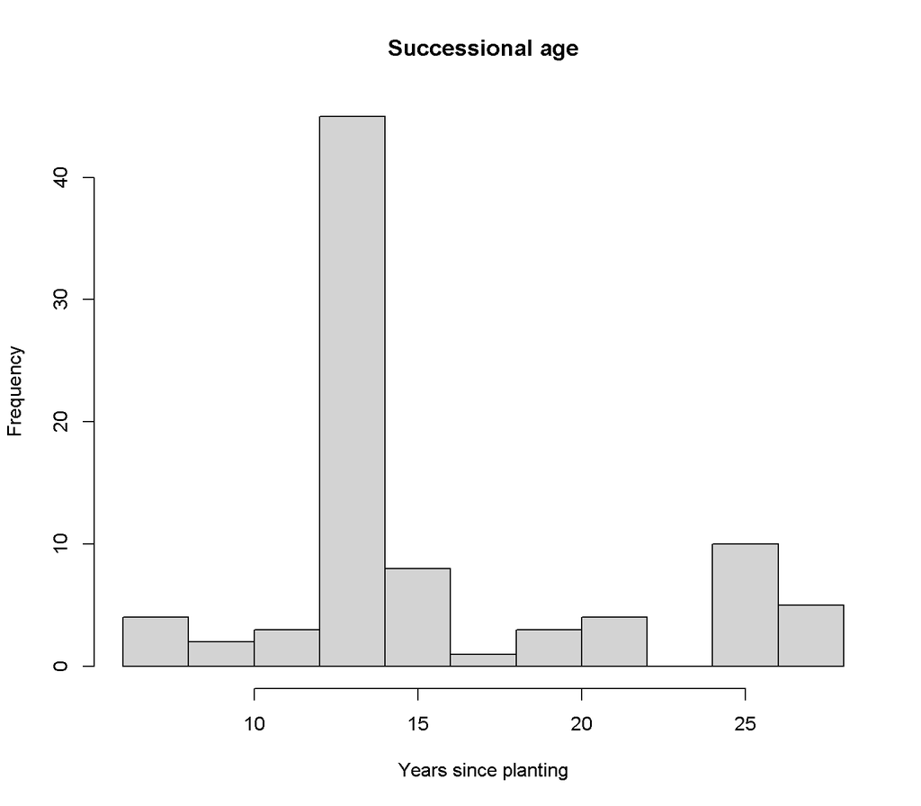

```r
safe_hist(age, main = "Successional age", xlab = "Years since planting")
```

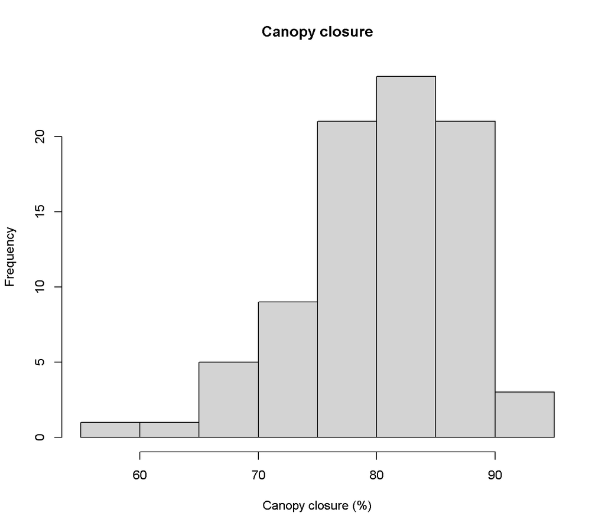

```r
safe_hist(canopy, main = "Canopy closure", xlab = "Canopy closure (%)")
```

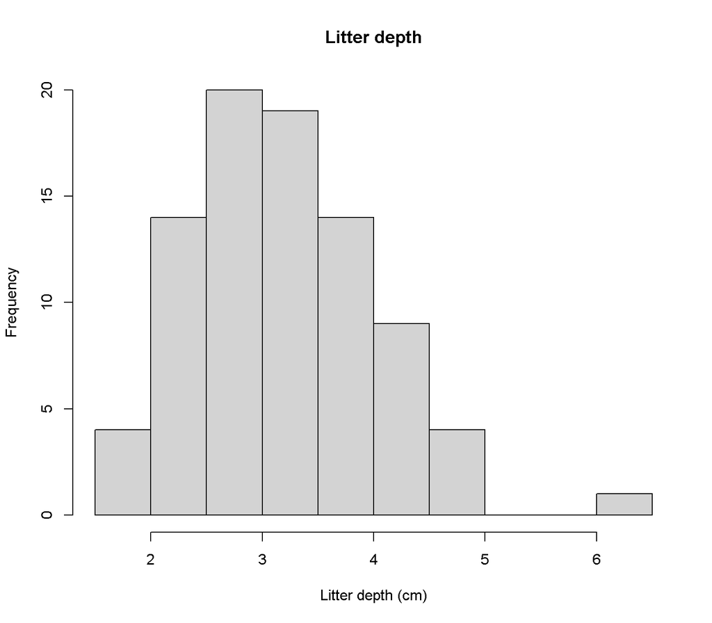

```r
safe_hist(litter, main = "Litter depth", xlab = "Litter depth (cm)")
```

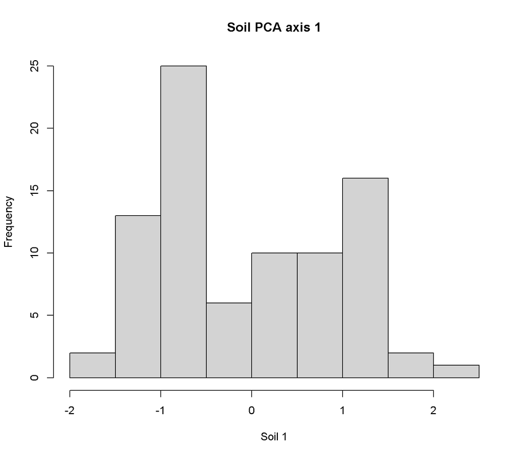

```r
safe_hist(soil1, main = "Soil PCA axis 1", xlab = "Soil 1")
```

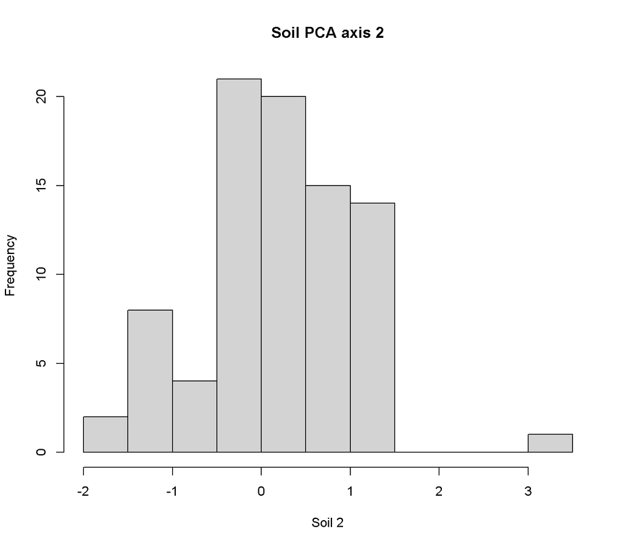

```r
safe_hist(soil2, main = "Soil PCA axis 2", xlab = "Soil 2")
```

```r
# Recruit response variables
safe_shapiro(r12S)
```

```
##
##  Shapiro-Wilk normality test
##
## data:  x_num
## W = 0.91277, p-value = 2.625e-05
```

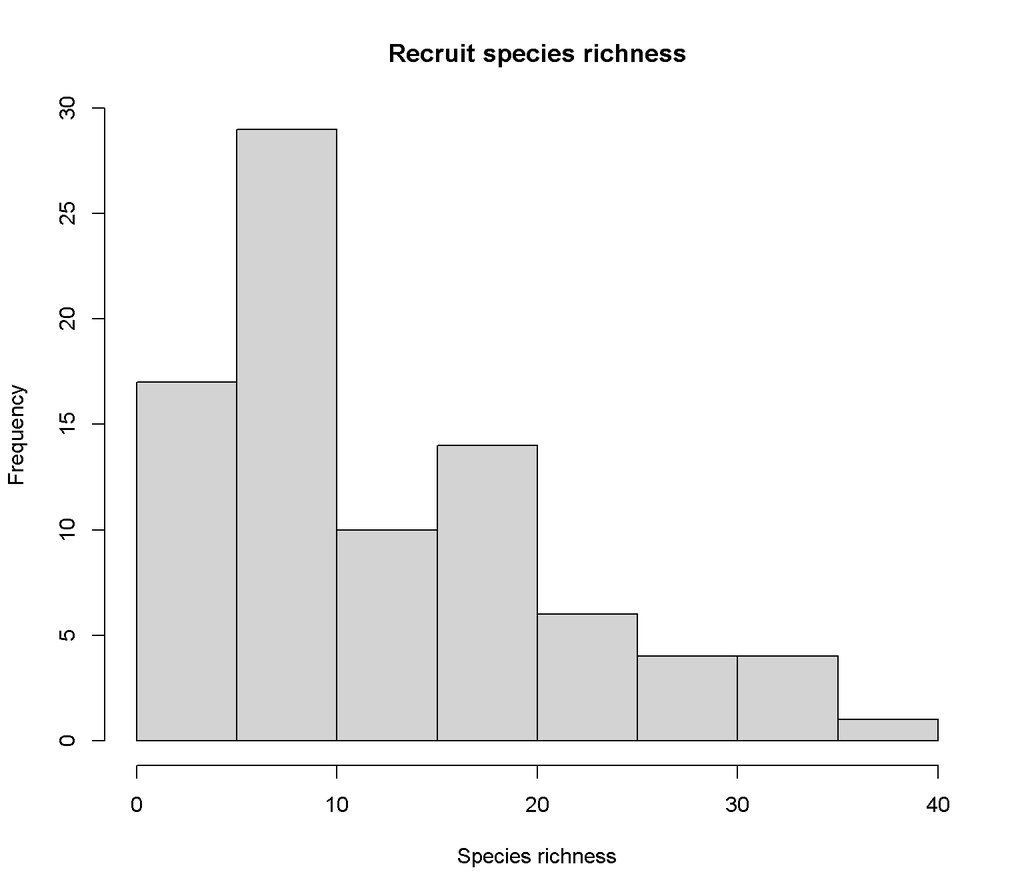

```r
safe_hist(r12S, main = "Recruit species richness", xlab = "Species richness")
```

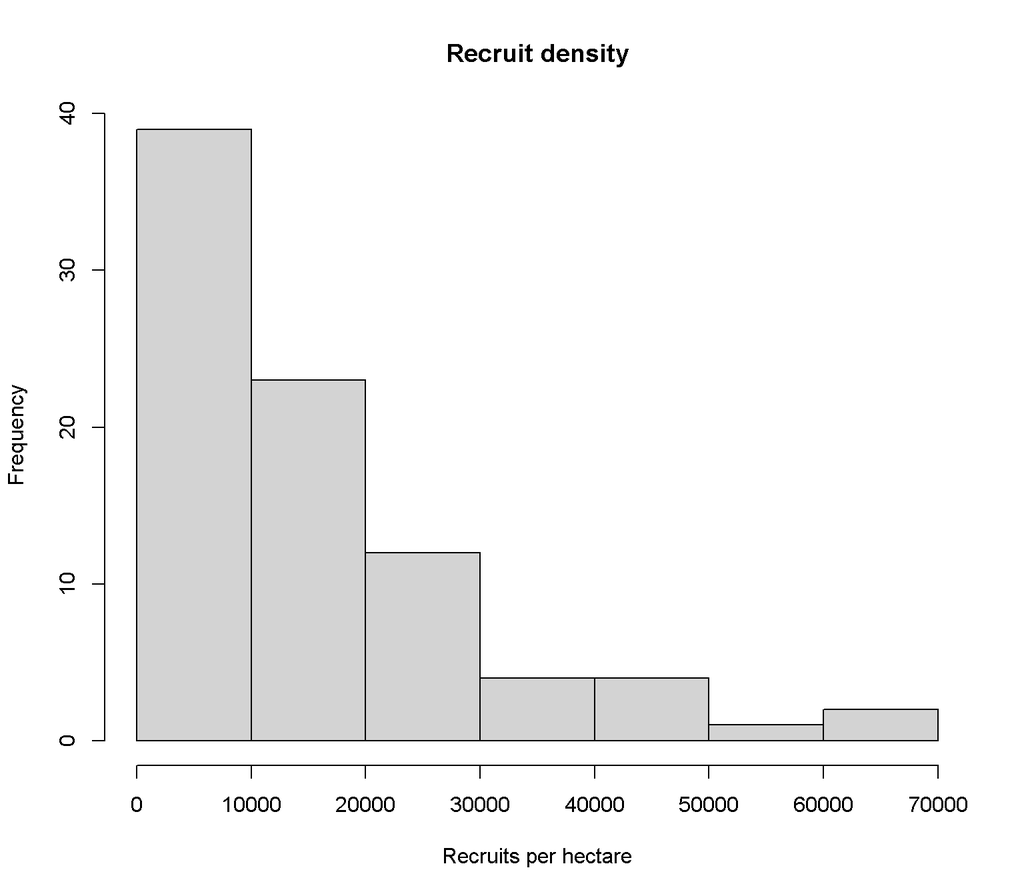

```r
safe_hist(r12dens, main = "Recruit density", xlab = "Recruits per hectare")
```

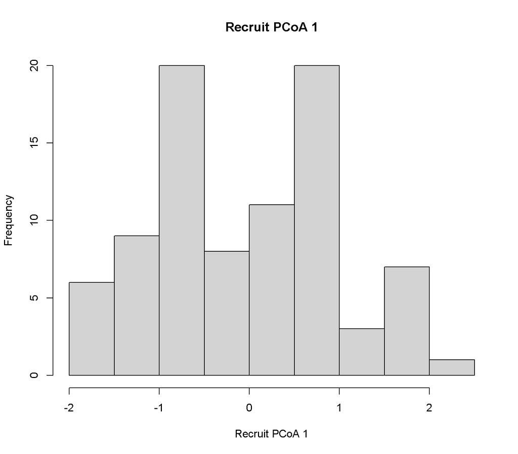

```r
safe_hist(r12_sc1, main = "Recruit PCoA 1", xlab = "Recruit PCoA 1")
```

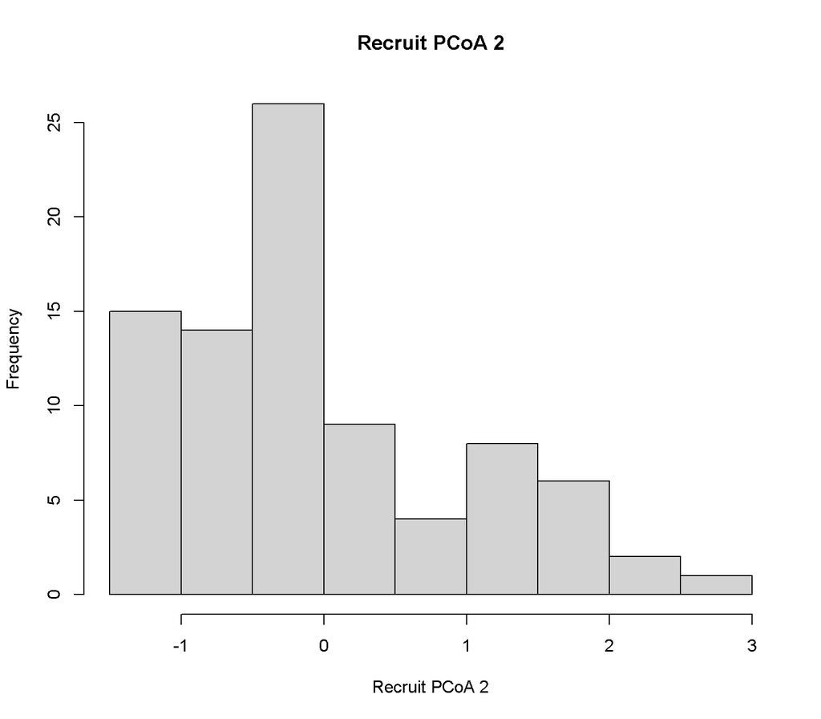

```r
safe_hist(r12_sc2, main = "Recruit PCoA 2", xlab = "Recruit PCoA 2")
```

```r
# Planted-tree predictors
safe_shapiro(pdens)
```

```
##
##  Shapiro-Wilk normality test
##
## data:  x_num
## W = 0.97344, p-value = 0.07635
```

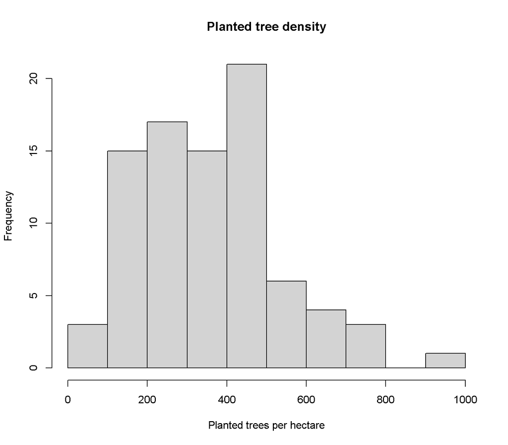

```r
safe_hist(pdens, main = "Planted tree density", xlab = "Planted trees per hectare")
```

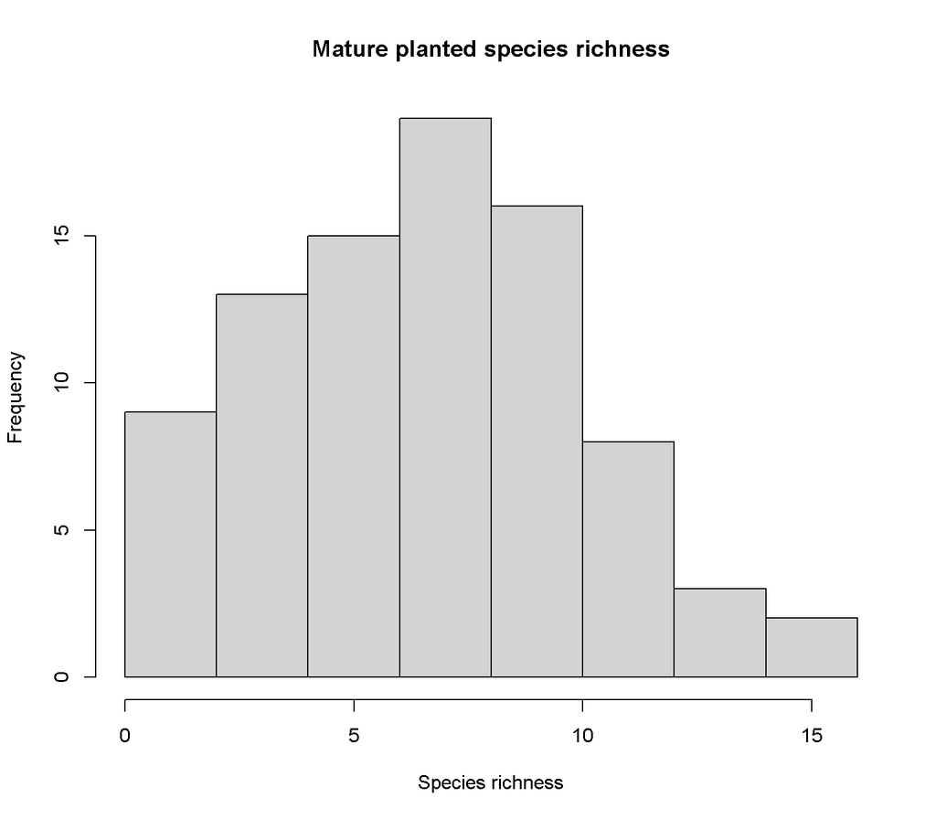

```r
safe_hist(mat_allS, main = "Mature planted species richness", xlab = "Species richness")
```

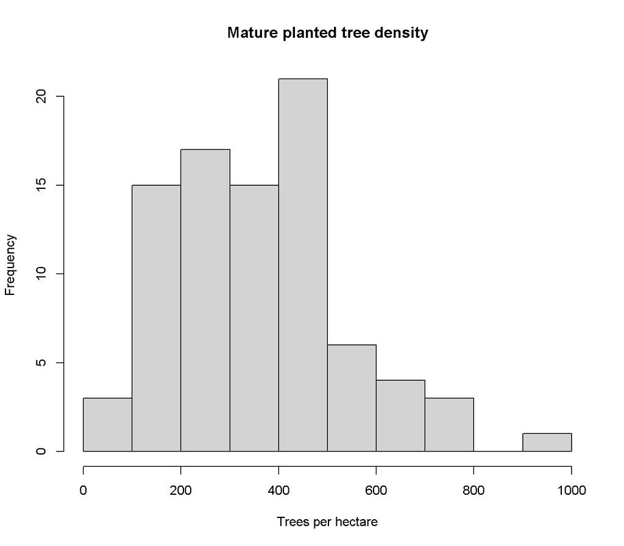

```r
safe_hist(mat_alldens, main = "Mature planted tree density", xlab = "Trees per hectare")
```

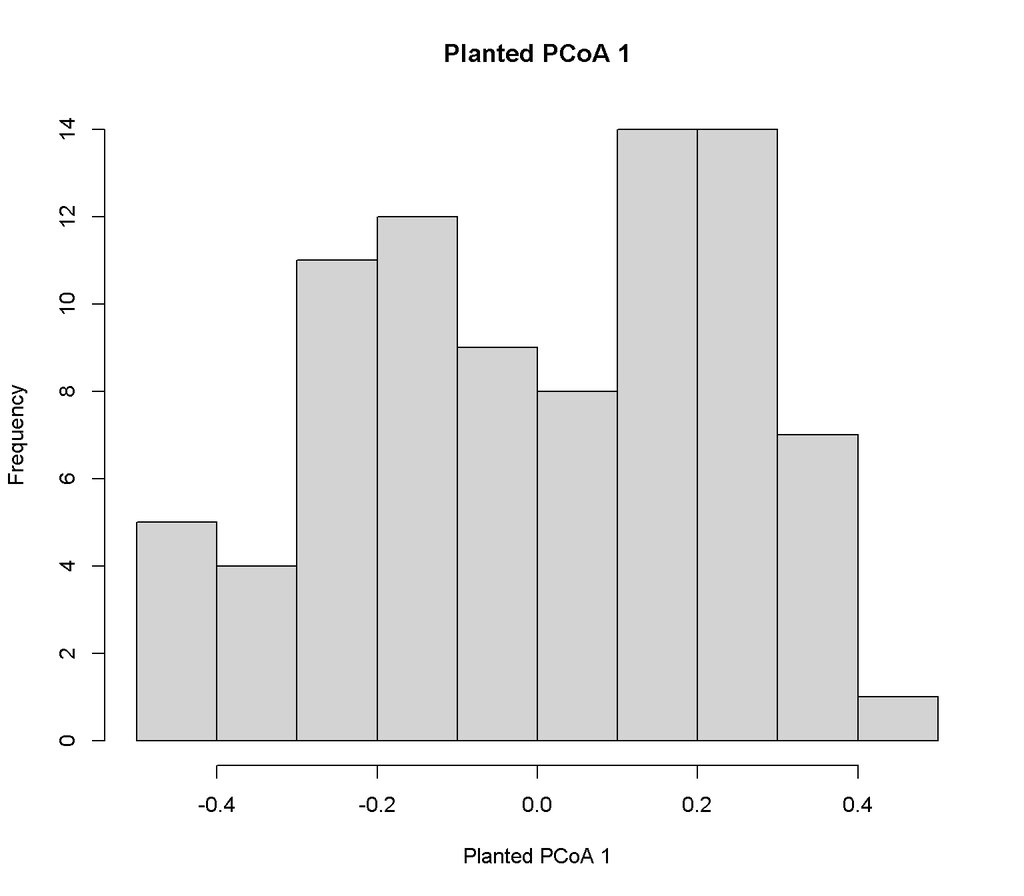

```r
safe_hist(mat_allsc1, main = "Planted PCoA 1", xlab = "Planted PCoA 1")
```

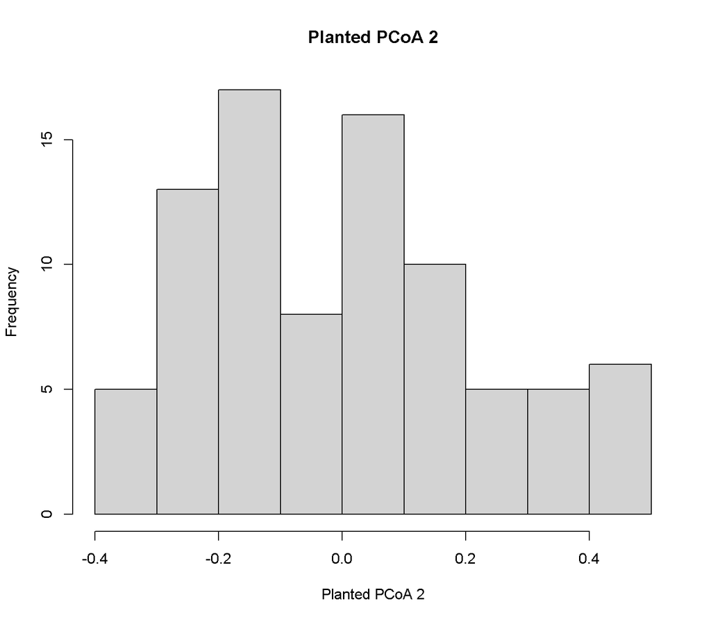

```r
safe_hist(mat_allsc2, main = "Planted PCoA 2", xlab = "Planted PCoA 2")
```

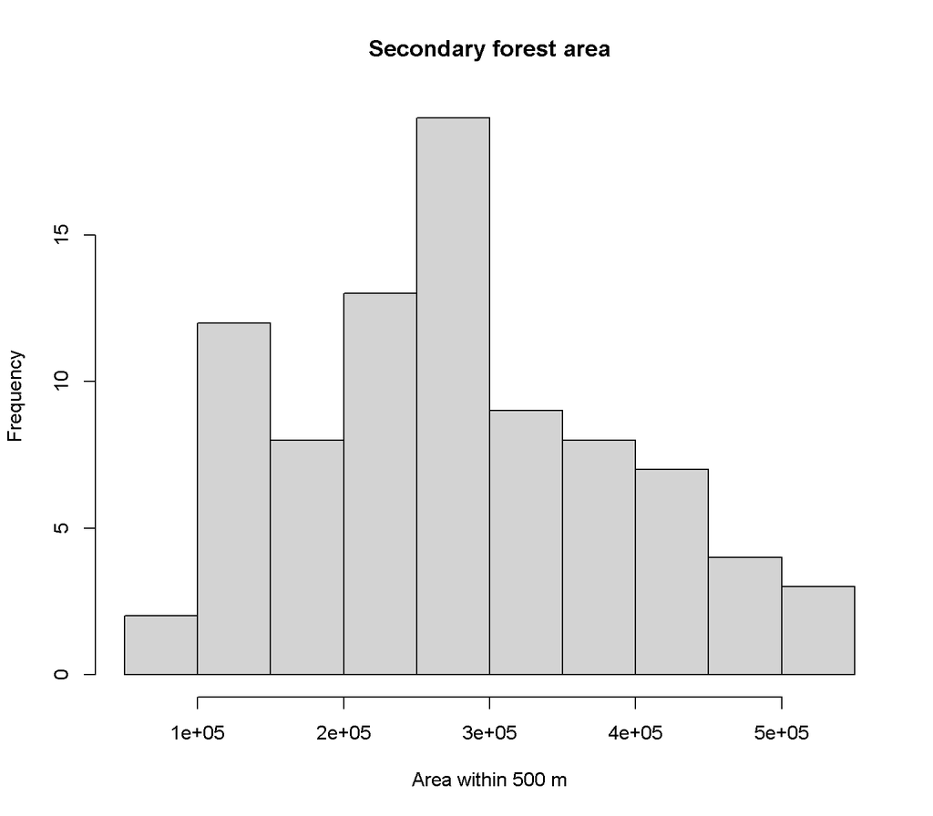

```r
# Surrounding forest area
safe_hist(sf_area, main = "Secondary forest area", xlab = "Area within 500 m")
```

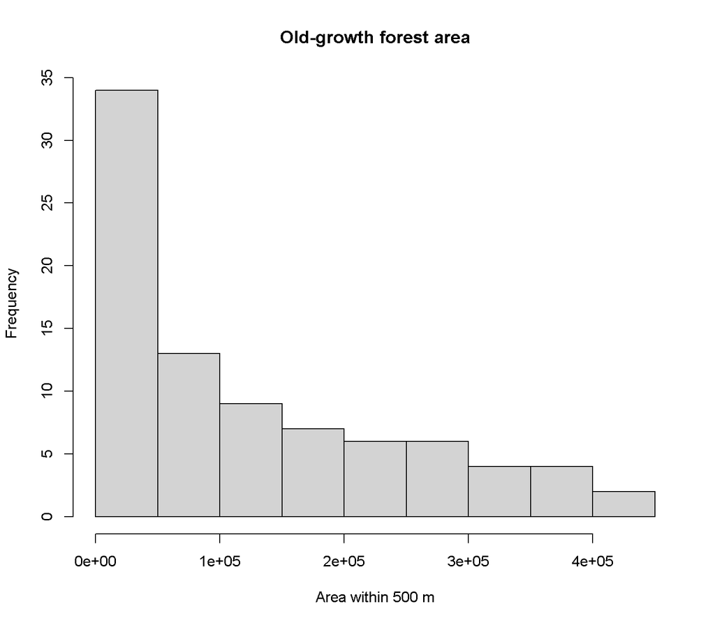

```r
safe_hist(ogf_area, main = "Old-growth forest area", xlab = "Area within 500 m")
```

## 5. Transformations and standardisation

The report states that continuous variables were transformed to improve normality and then standardised before modelling. The code below follows the original `data_rescale.R` file. Transformed variables are added to `data` so each model is explicit and reproducible.

```r
data <- data %>%
  mutate(
    # Site characteristics
    age = as.numeric(scale(log(planting_age2019))),
    canopy = as.numeric(scale(asin(sqrt(canopy_closure / 100)))),
    litter = as.numeric(scale(litter_depth)),
    soil1 = as.numeric(scale(soil_pca1)),
    soil2 = as.numeric(scale(soil_pca2)),

    # Recruit response variables
    r12S = as.numeric(scale(log(recruits12_S + 3))),
    r12dens = as.numeric(scale(recruits12_density^(1 / 4))),
    r12_sc1 = as.numeric(scale(recruits12_sc1)),
    r12_sc2 = as.numeric(scale(sqrt(recruits12_sc2 + 1.5))),

    # Mature planted-tree variables
    pdens = as.numeric(scale(sqrt(planted_density + 1000))),
    mat_allS = as.numeric(scale(mature_all_S)),
    mat_alldens = as.numeric(scale(mature_all_density)),
    mat_allsc1 = as.numeric(scale(mature_all_sc1)),
    mat_allsc2 = as.numeric(scale(mature_all_sc2)),

    # Surrounding forest area
    sf_area = as.numeric(scale(sqrt(area_sf))),
    ogf_area = as.numeric(scale(sqrt(area_ogf)))
  )
```

## 6. Model-checking workflow

Before fitting the response-specific mixed models, the original analysis checked correlations, residual structure and multicollinearity.

```r
# Spearman correlations among numeric variables.
chao_cor <- cor(data %>% select(where(is.numeric)), method = "spearman", use = "pairwise.complete.obs")
round(chao_cor[1:8, 1:8], 2)
```

```
##                    recruits12_S recruits12_density recruits12_sc1
## recruits12_S               1.00               0.84          -0.53
## recruits12_density         0.84               1.00          -0.62
## recruits12_sc1            -0.53              -0.62           1.00
## recruits12_sc2             0.09               0.10           0.04
## planting_age2019           0.28               0.33          -0.29
## mature_all_S               0.31               0.38          -0.29
## planted_density            0.11               0.11          -0.33
## mature_all_sc1             0.18               0.19          -0.14
##                    recruits12_sc2 planting_age2019 mature_all_S planted_density
## recruits12_S                 0.09             0.28         0.31            0.11
## recruits12_density           0.10             0.33         0.38            0.11
## recruits12_sc1               0.04            -0.29        -0.29           -0.33
## recruits12_sc2               1.00             0.09        -0.03           -0.21
## planting_age2019             0.09             1.00         0.24           -0.04
## mature_all_S                -0.03             0.24         1.00            0.47
## planted_density             -0.21            -0.04         0.47            1.00
## mature_all_sc1              -0.04             0.25         0.41            0.12
##                    mature_all_sc1
## recruits12_S                 0.18
## recruits12_density           0.19
## recruits12_sc1              -0.14
## recruits12_sc2              -0.04
## planting_age2019             0.25
## mature_all_S                 0.41
## planted_density              0.12
## mature_all_sc1               1.00
```

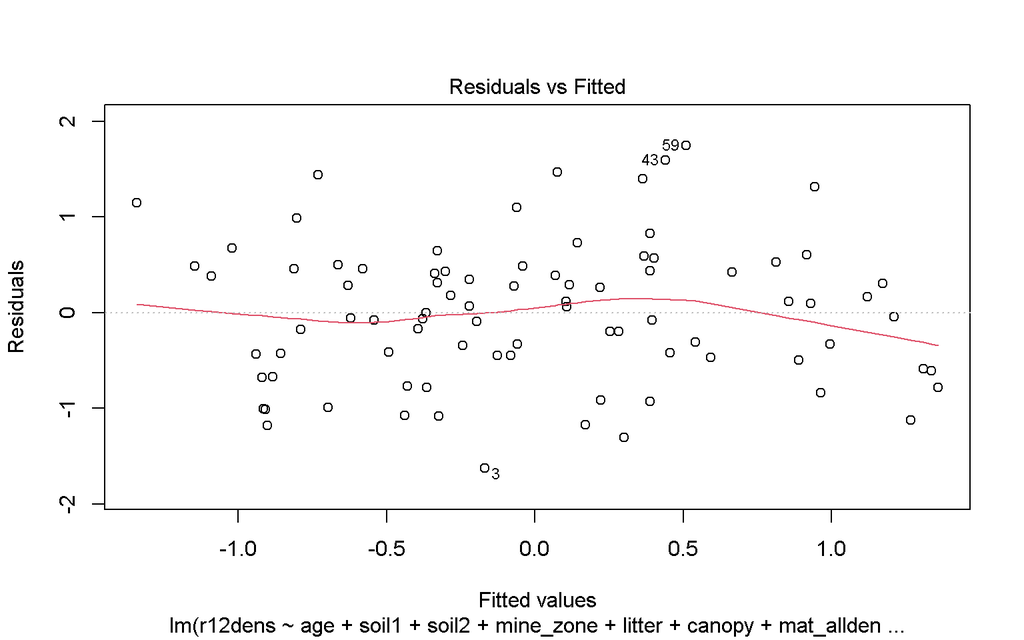

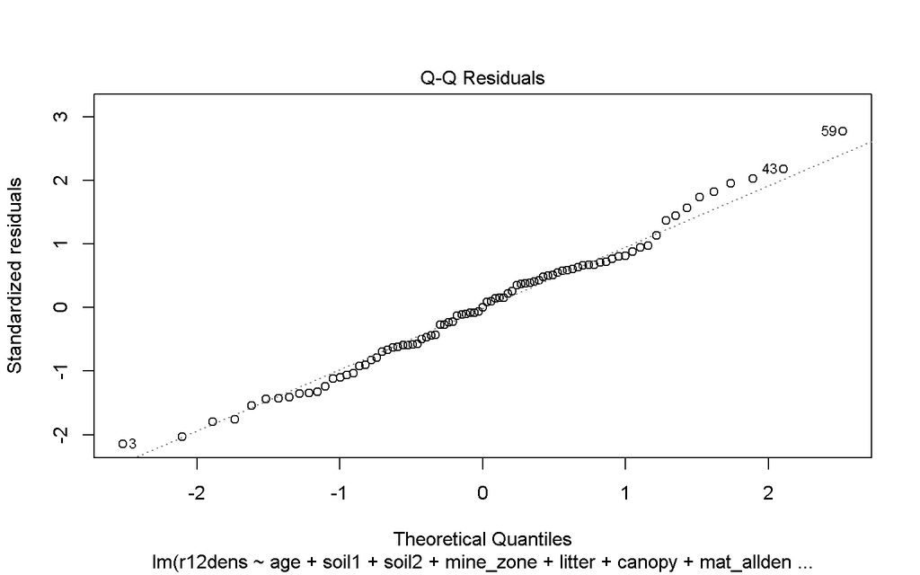

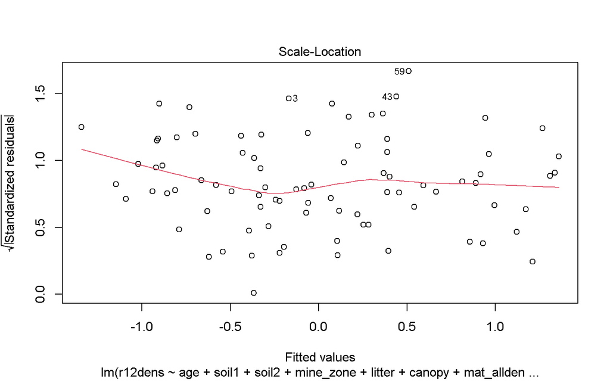

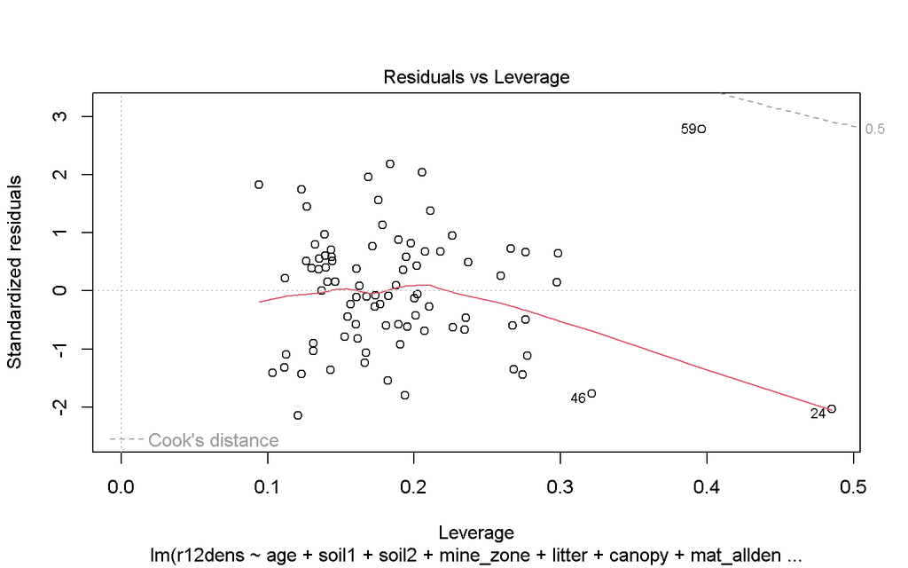

```r
# Heteroscedasticity and residual-pattern check using a broad linear model.
Reg_lm <- lm(
  r12dens ~ age + soil1 + soil2 + mine_zone + litter + canopy +
    mat_alldens + mat_allS + mat_allsc1 + mat_allsc2 + ogf_area + sf_area,
  data = data,
  na.action = na.omit
)
plot(Reg_lm)
```

```r
# VIF check using a broad mixed model.
Reg_vif1 <- lme(
  r12dens ~ age + soil1 + soil2 + mine_zone + litter + canopy +
    mat_alldens + mat_allS + mat_allsc1 + mat_allsc2,
  random = ~ 1 | mine,
  data = data,
  na.action = na.omit
)
vif.lme(Reg_vif1)
```

```
##                    age                  soil1                  soil2
##               1.974077               1.442694               1.576934
##  mine_zoneDry tailings  mine_zoneMining floor mine_zoneWashing plant
##               2.038048               1.877136               2.522780
##  mine_zoneWet tailings                 litter                 canopy
##               1.712606               1.266141               1.241922
##            mat_alldens               mat_allS             mat_allsc1
##               1.561111               2.305191               1.601578
##             mat_allsc2
##               1.538787
```

## 7. Random-effects structure

For each response variable, the original scripts compared three structures:

1. GLS model without random effects;
2. LMM with a random intercept for mine;
3. LMM with areas nested within mines.

The thesis retained mine as the random factor, accounting for the grouped sampling design while avoiding an unnecessarily complex random-effects structure.

```r
MD1 <- formula(
  r12dens ~ age +
    mat_alldens * soil1 +
    mat_alldens * soil2 +
    mat_alldens * mine_zone +
    mat_alldens * litter +
    mat_alldens * canopy
)

MD1_gls <- gls(MD1, data = data)
MD1_lme_mine <- lme(MD1, random = ~ 1 | mine, data = data, method = "REML")
MD1_lme_minea <- lme(MD1, random = ~ 1 | mine / area, data = data, method = "REML")

anova.lme(MD1_gls, MD1_lme_mine, MD1_lme_minea)
```

```
##               Model df      AIC      BIC    logLik   Test   L.Ratio p-value
## MD1_gls           1 20 257.7756 301.5687 -108.8878
## MD1_lme_mine      2 21 259.7518 305.7346 -108.8759 1 vs 2 0.0237354  0.8776
## MD1_lme_minea     3 22 259.1551 307.3275 -107.5775 2 vs 3 2.5967592  0.1071
```

The same comparison was performed for species richness and the two recruit-composition axes.

```r
MS1 <- formula(
  r12S ~ age +
    mat_alldens * soil1 + mat_allS * soil1 +
    ogf_area * soil1 + sf_area * soil1 +
    mat_alldens * soil2 + mat_allS * soil2 +
    ogf_area * soil2 + sf_area * soil2 +
    mat_alldens * mine_zone + mat_allS * mine_zone +
    ogf_area * mine_zone + sf_area * mine_zone +
    mat_alldens * litter + mat_allS * litter +
    ogf_area * litter + sf_area * litter +
    mat_alldens * canopy + mat_allS * canopy +
    ogf_area * canopy + sf_area * canopy
)

MS1_gls <- gls(MS1, data = data)
MS1_lme_mine <- lme(MS1, random = ~ 1 | mine, data = data, method = "REML")
MS1_lme_minea <- lme(MS1, random = ~ 1 | mine / area, data = data, method = "REML")
anova(MS1_gls, MS1_lme_mine, MS1_lme_minea)
```

```
##               Model df      AIC      BIC    logLik   Test      L.Ratio p-value
## MS1_gls           1 47 288.9167 367.1041 -97.45837
## MS1_lme_mine      2 48 290.9167 370.7677 -97.45837 1 vs 2 2.836759e-08  0.9999
## MS1_lme_minea     3 49 292.9167 374.4313 -97.45837 2 vs 3 7.701317e-09  0.9999
```

```r
MSc1_1 <- formula(
  r12_sc1 ~ age +
    mat_alldens + mat_allsc1 + mat_allsc2 + sf_area + ogf_area +
    soil1 + soil2 + mine_zone + litter + canopy +
    mat_alldens * soil1 + mat_allsc1 * soil1 + mat_allsc2 * soil1 +
    ogf_area * soil1 + sf_area * soil1 +
    mat_alldens * soil2 + mat_allsc1 * soil2 + mat_allsc2 * soil2 +
    ogf_area * soil2 + sf_area * soil2 +
    mat_alldens * mine_zone + mat_allsc1 * mine_zone + mat_allsc2 * mine_zone +
    ogf_area * mine_zone + sf_area * mine_zone +
    mat_alldens * litter + mat_allsc1 * litter + mat_allsc2 * litter +
    ogf_area * litter + sf_area * litter +
    mat_alldens * canopy + mat_allsc1 * canopy + mat_allsc2 * canopy +
    ogf_area * canopy + sf_area * canopy
)

MSc1_1_gls <- gls(MSc1_1, data = data)
MSc1_1_lme_mine <- lme(MSc1_1, random = ~ 1 | mine, data = data, method = "REML")
MSc1_1_lme_minea <- lme(MSc1_1, random = ~ 1 | mine / area, data = data, method = "REML")
anova(MSc1_1_gls, MSc1_1_lme_mine, MSc1_1_lme_minea)
```

```
##                  Model df      AIC      BIC    logLik   Test  L.Ratio p-value
## MSc1_1_gls           1 56 302.8197 381.2868 -95.40987
## MSc1_1_lme_mine      2 57 300.8855 380.7537 -93.44273 1 vs 2 3.934267  0.0473
## MSc1_1_lme_minea     3 58 302.8855 384.1549 -93.44273 2 vs 3 0.000000  0.9999
```

```r
MSc2_1 <- update(MSc1_1, r12_sc2 ~ .)
MSc2_1_gls <- gls(MSc2_1, data = data)
MSc2_1_lme_mine <- lme(MSc2_1, random = ~ 1 | mine, data = data, method = "REML")
MSc2_1_lme_minea <- lme(MSc2_1, random = ~ 1 | mine / area, data = data, method = "REML")
anova(MSc2_1_gls, MSc2_1_lme_mine, MSc2_1_lme_minea)
```

```
##                  Model df      AIC      BIC    logLik   Test   L.Ratio p-value
## MSc2_1_gls           1 56 323.6309 402.0979 -105.8154
## MSc2_1_lme_mine      2 57 325.6309 405.4991 -105.8154 1 vs 2 0.0000000  0.9999
## MSc2_1_lme_minea     3 58 326.9934 408.2629 -105.4967 2 vs 3 0.6374452  0.4246
```

## 8. Candidate models, variable selection and final models

Models were first fitted using maximum likelihood for model comparison and variable selection, then refitted using REML for final interpretation.

### 8.1 Recruit species richness

The report evaluated recruit species richness as a function of successional age, canopy closure, soil properties, planted community variables, surrounding forest area and mine-zone interactions.

```r
MS1_ML <- lme(MS1, random = ~ 1 | mine, data = data, method = "ML")
coef(summary(MS1_ML))
```

```
##                                           Value Std.Error DF     t-value
## (Intercept)                         0.576622194 0.4934043 35  1.16866061
## age                                 0.280156528 0.2013931 35  1.39109279
## mat_alldens                         0.062326112 0.1960980 35  0.31783153
## soil1                              -0.564573635 0.2558082 35 -2.20701899
## mat_allS                            0.020561212 0.2894570 35  0.07103375
## ogf_area                           -0.716448006 0.4041948 35 -1.77253156
## sf_area                            -0.750893931 0.4695188 35 -1.59928419
## soil2                              -0.282154325 0.1802384 35 -1.56545103
## mine_zoneDry tailings              -1.172365659 0.6113775 35 -1.91758073
## mine_zoneMining floor              -0.671198971 0.7486104 35 -0.89659317
## mine_zoneWashing plant             -1.557959668 1.5333724  4 -1.01603480
## mine_zoneWet tailings              -4.917580661 3.1850361 35 -1.54396388
## litter                             -0.049813989 0.1344596 35 -0.37047543
## canopy                              0.118009496 0.1280626 35  0.92149869
## mat_alldens:soil1                  -0.073548299 0.1782912 35 -0.41251777
## soil1:mat_allS                     -0.027157023 0.2190482 35 -0.12397741
## soil1:ogf_area                      0.596717591 0.3080509 35  1.93707437
## soil1:sf_area                       0.005947776 0.3467588 35  0.01715249
## mat_alldens:soil2                  -0.057781179 0.1940599 35 -0.29774922
## mat_allS:soil2                      0.396904816 0.2025273 35  1.95975912
## ogf_area:soil2                      0.370888330 0.2194614 35  1.68999379
## sf_area:soil2                       0.454348985 0.2327789 35  1.95184783
## mat_alldens:mine_zoneDry tailings  -0.345565564 0.4005012 35 -0.86283273
## mat_alldens:mine_zoneMining floor  -0.181102436 0.4001752 35 -0.45255793
## mat_alldens:mine_zoneWashing plant -0.205958197 0.4548055 35 -0.45284892
## mat_alldens:mine_zoneWet tailings  -0.354352038 0.5968871 35 -0.59366675
## mat_allS:mine_zoneDry tailings      0.543602871 0.3513040 35  1.54738604
## mat_allS:mine_zoneMining floor     -0.430727787 0.4271678 35 -1.00833389
## mat_allS:mine_zoneWashing plant     0.514391961 0.5998361 35  0.85755415
## mat_allS:mine_zoneWet tailings     -0.588025883 0.9178547 35 -0.64065249
## ogf_area:mine_zoneDry tailings      1.560100418 0.5297274 35  2.94510065
## ogf_area:mine_zoneMining floor      1.437068399 0.6722335 35  2.13775176
## ogf_area:mine_zoneWashing plant     2.071953740 1.1511702 35  1.79986738
## ogf_area:mine_zoneWet tailings      2.162719728 1.8371703 35  1.17720155
## sf_area:mine_zoneDry tailings       1.621113934 0.6421043 35  2.52468947
## sf_area:mine_zoneMining floor       0.409811468 0.9060022 35  0.45232943
## sf_area:mine_zoneWashing plant      0.893271721 0.7247808 35  1.23247157
## sf_area:mine_zoneWet tailings      -2.867010301 2.7943433 35 -1.02600505
## mat_alldens:litter                 -0.136556995 0.1284365 35 -1.06322555
```

[output cut: 39 more lines]

```
## ogf_area:mine_zoneMining floor     0.03959847
## ogf_area:mine_zoneWashing plant    0.08050683
## ogf_area:mine_zoneWet tailings     0.24705867
## sf_area:mine_zoneDry tailings      0.01626657
## sf_area:mine_zoneMining floor      0.65382287
## sf_area:mine_zoneWashing plant     0.22598815
## sf_area:mine_zoneWet tailings      0.31192831
## mat_alldens:litter                 0.29496070
## mat_allS:litter                    0.84081373
## ogf_area:litter                    0.92661470
## sf_area:litter                     0.66004189
## mat_alldens:canopy                 0.25456698
## mat_allS:canopy                    0.77169158
## ogf_area:canopy                    0.23620249
## sf_area:canopy                     0.26858573
```

```r
AIC(MS1_ML)
```

```
## [1] 205.791
```

```r
MS2_ML <- lme(
  r12S ~ age + ogf_area + soil1 + canopy +
    mat_alldens:soil1 + ogf_area * soil1 +
    mat_allS:soil2 +
    ogf_area:mine_zone + sf_area:mine_zone +
    mat_alldens:litter +
    mat_alldens:canopy + ogf_area * canopy,
  random = ~ 1 | mine,
  data = data,
  method = "ML"
)
coef(summary(MS2_ML))
```

```
##                                         Value  Std.Error DF     t-value
## (Intercept)                      -0.008381198 0.12150033 60 -0.06898086
## age                               0.369151923 0.09218359 60  4.00452973
## ogf_area                         -0.610768282 0.26886274 60 -2.27167323
## soil1                            -0.416982345 0.10560675 60 -3.94844422
## canopy                            0.223935165 0.09316896 60  2.40353831
## soil1:mat_alldens                -0.245665873 0.10082764 60 -2.43649327
## ogf_area:soil1                    0.376803601 0.12047507 60  3.12764796
## mat_allS:soil2                    0.340410365 0.10261621 60  3.31731574
## ogf_area:mine_zoneDry tailings    1.313174725 0.34104967 60  3.85039143
## ogf_area:mine_zoneMining floor    0.737013912 0.36833623 60  2.00092703
## ogf_area:mine_zoneWashing plant   1.192589774 0.38487409 60  3.09864915
## ogf_area:mine_zoneWet tailings    0.313794803 0.50667931 60  0.61931639
## mine_zoneCapped tailings:sf_area -0.287765289 0.21838721 60 -1.31768379
## mine_zoneDry tailings:sf_area     0.591856524 0.22800329 60  2.59582448
## mine_zoneMining floor:sf_area    -0.407871898 0.50466331 60 -0.80820596
## mine_zoneWashing plant:sf_area    0.139334530 0.27881124 60  0.49974502
## mine_zoneWet tailings:sf_area     0.535909630 0.24692836 60  2.17030409
## mat_alldens:litter               -0.194418997 0.07083217 60 -2.74478403
## canopy:mat_alldens                0.262878699 0.08529442 60  3.08201521
## ogf_area:canopy                  -0.258044061 0.09858065 60 -2.61759330
##                                       p-value
## (Intercept)                      0.9452342358
## age                              0.0001736809
## ogf_area                         0.0267057308
## soil1                            0.0002092493
## canopy                           0.0193443055
## soil1:mat_alldens                0.0178149997
## ogf_area:soil1                   0.0027178823
## mat_allS:soil2                   0.0015473793
## ogf_area:mine_zoneDry tailings   0.0002889116
## ogf_area:mine_zoneMining floor   0.0499302509
## ogf_area:mine_zoneWashing plant  0.0029573275
## ogf_area:mine_zoneWet tailings   0.5380525801
## mine_zoneCapped tailings:sf_area 0.1926188424
## mine_zoneDry tailings:sf_area    0.0118475019
## mine_zoneMining floor:sf_area    0.4221649461
## mine_zoneWashing plant:sf_area   0.6190824357
## mine_zoneWet tailings:sf_area    0.0339526969
## mat_alldens:litter               0.0079764988
## canopy:mat_alldens               0.0031034377
## ogf_area:canopy                  0.0111914411
```

```r
AIC(MS2_ML)
```

```
## [1] 190.9525
```

```r
r.squaredGLMM(MS2_ML)
```

```
##            R2m       R2c
## [1,] 0.6688186 0.6688186
```

```r
MS3_fix <- lmer(
  r12S ~ age + ogf_area + soil1 + canopy +
    mat_alldens:soil1 + ogf_area * soil1 +
    mat_allS:soil2 +
    ogf_area:mine_zone + sf_area:mine_zone +
    mat_alldens:litter +
    mat_alldens:canopy + ogf_area * canopy +
    (1 | mine),
  data = data,
  REML = FALSE
)

MS_varselection <- step(
  MS3_fix,
  ddf = "Satterthwaite",
  alpha.fixed = 0.05,
  direction = "backward",
  reduce.fixed = TRUE,
  reduce.random = FALSE
)
MS_varselection
```

```
## Backward reduced random-effect table:
##
##            Eliminated npar  logLik    AIC         LRT Df Pr(>Chisq)
## <none>                  22 -73.476 190.95
## (1 | mine)          0   21 -73.476 188.95 -2.8422e-14  1          1
##
## Backward reduced fixed-effect table:
## Degrees of freedom method: Satterthwaite
##
##                    Eliminated Sum Sq Mean Sq NumDF DenDF F value    Pr(>F)
## age                         0 6.9178  6.9178     1    85 20.9705 1.583e-05 ***
## soil1:mat_alldens           0 2.5609  2.5609     1    85  7.7631 0.0065749 **
## ogf_area:soil1              0 4.2199  4.2199     1    85 12.7921 0.0005775 ***
## mat_allS:soil2              0 4.7472  4.7472     1    85 14.3906 0.0002773 ***
## ogf_area:mine_zone          0 7.8187  1.9547     4    85  5.9254 0.0002963 ***
## mine_zone:sf_area           0 7.3274  1.4655     5    85  4.4425 0.0012111 **
## mat_alldens:litter          0 3.2500  3.2500     1    85  9.8519 0.0023326 **
## canopy:mat_alldens          0 4.0976  4.0976     1    85 12.4215 0.0006861 ***
## ogf_area:canopy             0 2.9557  2.9557     1    85  8.9600 0.0036125 **
## ---
## Signif. codes:  0 '***' 0.001 '**' 0.01 '*' 0.05 '.' 0.1 ' ' 1
##
## Model found:
## r12S ~ age + ogf_area + soil1 + canopy + mat_alldens:soil1 + ogf_area * soil1 + mat_allS:soil2 + ogf_area:mine_zone + sf_area:mine_zone + mat_alldens:litter + mat_alldens:canopy + ogf_area * canopy + (1 | mine)
```

```r
MS_final <- lme(
  r12S ~ mat_allS:soil2 +
    canopy:mat_allsc2 +
    canopy + age +
    mat_allsc2:mine_zone +
    mine_zone:ogf_area,
  random = ~ 1 | mine,
  data = data,
  method = "REML"
)

coef(summary(MS_final))
```

```
##                                         Value  Std.Error DF    t-value
## (Intercept)                        0.02340319 0.10689330 66  0.2189397
## canopy                             0.25848503 0.10043532 66  2.5736467
## age                                0.28546790 0.10389364 66  2.7476938
## mat_allS:soil2                     0.42093762 0.10620603 66  3.9634059
## canopy:mat_allsc2                  0.36422978 0.09330905 66  3.9034776
## mat_allsc2:mine_zoneDry tailings  -0.60263240 0.17373785 66 -3.4686305
## mat_allsc2:mine_zoneMining floor  -0.25549405 0.17343415 66 -1.4731473
## mat_allsc2:mine_zoneWashing plant  0.31131045 0.27061524 66  1.1503804
## mat_allsc2:mine_zoneWet tailings  -0.46494302 0.37715593 66 -1.2327607
## mine_zoneCapped tailings:ogf_area -0.19149797 0.20296214 66 -0.9435157
## mine_zoneDry tailings:ogf_area     0.42307387 0.20786395 66  2.0353403
## mine_zoneMining floor:ogf_area    -0.21742498 0.22336150 66 -0.9734219
## mine_zoneWashing plant:ogf_area    0.46777304 0.19337550 66  2.4189881
## mine_zoneWet tailings:ogf_area    -0.05082616 0.47933939 66 -0.1060338
##                                        p-value
## (Intercept)                       0.8273726405
## canopy                            0.0123165605
## age                               0.0077304152
## mat_allS:soil2                    0.0001840946
## canopy:mat_allsc2                 0.0002252590
## mat_allsc2:mine_zoneDry tailings  0.0009260423
## mat_allsc2:mine_zoneMining floor  0.1454647265
## mat_allsc2:mine_zoneWashing plant 0.2541383407
## mat_allsc2:mine_zoneWet tailings  0.2220381674
## mine_zoneCapped tailings:ogf_area 0.3488583086
## mine_zoneDry tailings:ogf_area    0.0458354992
## mine_zoneMining floor:ogf_area    0.3338978769
## mine_zoneWashing plant:ogf_area   0.0183284749
## mine_zoneWet tailings:ogf_area    0.9158771936
```

```r
AIC(MS_final)
```

```
## [1] 233.7587
```

```r
r.squaredGLMM(MS_final)
```

```
##            R2m       R2c
## [1,] 0.4928117 0.4928117
```

```r
model.sel(MS1_ML, MS2_ML)
```

```
## Model selection table
##            (Int)    age    cnp      ltt mat_all mat_alS min_zon ogf_are  sf_are
## MS2_ML -0.008381 0.3692 0.2239                                  -0.6108
## MS1_ML  0.576600 0.2802 0.1180 -0.04981 0.06233 0.02056       + -0.7164 -0.7509
##            sl1     sl2 cnp:mat_all cnp:mat_alS cnp:ogf_are cnp:sf_are
## MS2_ML -0.4170              0.2629                 -0.2580
## MS1_ML -0.5646 -0.2822      0.1722    -0.04935     -0.1975     0.2201
##        ltt:mat_all ltt:mat_alS ltt:ogf_are ltt:sf_are mat_all:min_zon
## MS2_ML     -0.1944
## MS1_ML     -0.1366     0.03606    -0.01812    0.06946               +
##        mat_all:sl1 mat_all:sl2 mat_alS:min_zon mat_alS:sl1 mat_alS:sl2
## MS2_ML    -0.24570                                              0.3404
## MS1_ML    -0.07355    -0.05778               +    -0.02716      0.3969
##        min_zon:ogf_are min_zon:sf_are ogf_are:sl1 ogf_are:sl2 sf_are:sl1
## MS2_ML               +              +      0.3768
## MS1_ML               +              +      0.5967      0.3709   0.005948
##        sf_are:sl2 df  logLik  AICc  delta weight
## MS2_ML            22 -73.476 207.3   0.00      1
## MS1_ML     0.4543 48 -54.896 336.5 129.18      0
## Models ranked by AICc(x)
## Random terms (all models):
##   1 | mine
```

```r
std.coef(MS_final, partial.sd = TRUE)
```

```
##                                    Estimate* Std. Error* df
## (Intercept)                        0.0000000   0.0000000 66
## canopy                             0.2070975   0.0804685 66
## age                                0.2211028   0.0804685 66
## mat_allS:soil2                     0.3189293   0.0804685 66
## canopy:mat_allsc2                  0.3141070   0.0804685 66
## mat_allsc2:mine_zoneDry tailings  -0.2791155   0.0804685 66
## mat_allsc2:mine_zoneMining floor  -0.1185420   0.0804685 66
## mat_allsc2:mine_zoneWashing plant  0.0925694   0.0804685 66
## mat_allsc2:mine_zoneWet tailings  -0.0991984   0.0804685 66
## mine_zoneCapped tailings:ogf_area -0.0759233   0.0804685 66
## mine_zoneDry tailings:ogf_area     0.1637808   0.0804685 66
## mine_zoneMining floor:ogf_area    -0.0783298   0.0804685 66
## mine_zoneWashing plant:ogf_area    0.1946524   0.0804685 66
## mine_zoneWet tailings:ogf_area    -0.0085324   0.0804685 66
```

### 8.2 Recruit species composition: PCoA axis 1

Recruit PCoA 1 represented a gradient from *Myrcia splendens*-dominated recruit communities to *Psidium guianensis*-dominated recruit communities. The final model retained site age, planted-tree density, surrounding forest area, soil axis 1, mine-zone effects and interactions with planted composition and soil axis 2.

```r
MSc1_1_ML <- lme(MSc1_1, random = ~ 1 | mine, data = data, method = "ML")
coef(summary(MSc1_1_ML))
```

```
##                                           Value  Std.Error DF      t-value
## (Intercept)                        -0.171365130 0.60506073 26 -0.283219721
## age                                -0.441873656 0.18594650 26 -2.376348340
## mat_alldens                        -0.213647738 0.18536735 26 -1.152564034
## mat_allsc1                          0.149494485 0.17024153 26  0.878131706
## mat_allsc2                          0.005858057 0.25508731 26  0.022964909
## sf_area                            -0.183348356 0.41268606 26 -0.444280472
## ogf_area                            0.089345912 0.46051649 26  0.194012405
## soil1                               0.335921407 0.24389186 26  1.377337489
## soil2                              -0.253372901 0.26424623 26 -0.958851521
## mine_zoneDry tailings              -0.532043208 0.58717149 26 -0.906112123
## mine_zoneMining floor              -0.635707047 0.65298465 26 -0.973540573
## mine_zoneWashing plant              1.562280391 1.39898094  4  1.116727427
## mine_zoneWet tailings              -0.283103708 2.56451263 26 -0.110392791
## litter                             -0.154119759 0.12320289 26 -1.250942700
## canopy                             -0.214024620 0.13813909 26 -1.549341424
## mat_alldens:soil1                  -0.057700052 0.16725637 26 -0.344979686
## mat_allsc1:soil1                    0.106952146 0.13386307 26  0.798966759
## mat_allsc2:soil1                   -0.131321612 0.14746377 26 -0.890534744
## ogf_area:soil1                     -0.141284869 0.22953415 26 -0.615528763
## sf_area:soil1                      -0.122132381 0.27752635 26 -0.440074893
## mat_alldens:soil2                  -0.153164535 0.19590859 26 -0.781816338
## mat_allsc1:soil2                   -0.252030795 0.18149153 26 -1.388664194
## mat_allsc2:soil2                    0.197642363 0.15405489 26  1.282934702
## ogf_area:soil2                      0.129029672 0.21841229 26  0.590761953
## sf_area:soil2                      -0.108724537 0.25870097 26 -0.420271083
## mat_alldens:mine_zoneDry tailings   0.643299296 0.38081744 26  1.689259033
## mat_alldens:mine_zoneMining floor  -0.586434085 0.39382501 26 -1.489072723
## mat_alldens:mine_zoneWashing plant -0.036850270 0.30624477 26 -0.120329468
## mat_alldens:mine_zoneWet tailings   0.112602875 0.60009221 26  0.187642621
## mat_allsc1:mine_zoneDry tailings   -0.087803319 0.27593498 26 -0.318202926
## mat_allsc1:mine_zoneMining floor    0.002527134 0.31181062 26  0.008104709
## mat_allsc1:mine_zoneWashing plant   0.417472578 0.32243733 26  1.294740207
## mat_allsc1:mine_zoneWet tailings    0.443359782 0.44838269 26  0.988797727
## mat_allsc2:mine_zoneDry tailings    0.344449001 0.31906673 26  1.079551597
## mat_allsc2:mine_zoneMining floor   -0.799254009 0.45531163 26 -1.755399953
## mat_allsc2:mine_zoneWashing plant   0.008388553 0.44088646 26  0.019026560
## mat_allsc2:mine_zoneWet tailings    0.365820688 0.53654731 26  0.681805097
## ogf_area:mine_zoneDry tailings     -0.076764762 0.44212464 26 -0.173626969
## ogf_area:mine_zoneMining floor     -0.448288369 0.66171969 26 -0.677459616
```

[output cut: 57 more lines]

```
## ogf_area:mine_zoneWet tailings     0.71603621
## sf_area:mine_zoneDry tailings      0.58211156
## sf_area:mine_zoneMining floor      0.26523244
## sf_area:mine_zoneWashing plant     0.68534779
## sf_area:mine_zoneWet tailings      0.53436283
## mat_alldens:litter                 0.57366560
## mat_allsc1:litter                  0.87422689
## mat_allsc2:litter                  0.45088399
## ogf_area:litter                    0.81564071
## sf_area:litter                     0.24772013
## mat_alldens:canopy                 0.13938105
## mat_allsc1:canopy                  0.46251952
## mat_allsc2:canopy                  0.96845644
## ogf_area:canopy                    0.32990995
## sf_area:canopy                     0.85452875
```

```r
AIC(MSc1_1_ML)
```

```
## [1] 169.1706
```

```r
MSc1_2_ML <- lme(
  r12_sc1 ~ age + mat_alldens +
    sf_area + ogf_area +
    soil1 + mine_zone +
    mat_alldens:soil2 +
    mine_zone:mat_allsc2,
  random = ~ 1 | mine,
  data = data,
  method = "ML"
)
coef(summary(MSc1_2_ML))
```

```
##                                           Value  Std.Error DF    t-value
## (Intercept)                         -0.10686934 0.15889218 65 -0.6725903
## age                                 -0.29706070 0.08584259 65 -3.4605279
## mat_alldens                         -0.20925478 0.07625176 65 -2.7442616
## sf_area                             -0.25389185 0.10225685 65 -2.4828836
## ogf_area                            -0.31881853 0.09235140 65 -3.4522327
## soil1                                0.46148662 0.07726661 65  5.9726526
## mine_zoneDry tailings               -0.04377954 0.18686015 65 -0.2342904
## mine_zoneMining floor               -0.75281625 0.23917595 65 -3.1475416
## mine_zoneWashing plant               0.68037239 0.30697164  4  2.2164015
## mine_zoneWet tailings                0.75428957 0.30098701 65  2.5060536
## mat_alldens:soil2                   -0.20447790 0.08103920 65 -2.5231974
## mine_zoneCapped tailings:mat_allsc2 -0.04446976 0.13116725 65 -0.3390310
## mine_zoneDry tailings:mat_allsc2     0.12156547 0.12518551 65  0.9710826
## mine_zoneMining floor:mat_allsc2    -0.36190644 0.13489604 65 -2.6828545
## mine_zoneWashing plant:mat_allsc2    0.14222776 0.22287579 65  0.6381481
## mine_zoneWet tailings:mat_allsc2     0.26464483 0.26334190 65  1.0049477
##                                          p-value
## (Intercept)                         5.035921e-01
## age                                 9.573657e-04
## mat_alldens                         7.831461e-03
## sf_area                             1.562271e-02
## ogf_area                            9.825428e-04
## soil1                               1.079077e-07
## mine_zoneDry tailings               8.154960e-01
## mine_zoneMining floor               2.485681e-03
## mine_zoneWashing plant              9.097564e-02
## mine_zoneWet tailings               1.472106e-02
## mat_alldens:soil2                   1.408442e-02
## mine_zoneCapped tailings:mat_allsc2 7.356793e-01
## mine_zoneDry tailings:mat_allsc2    3.351070e-01
## mine_zoneMining floor:mat_allsc2    9.246837e-03
## mine_zoneWashing plant:mat_allsc2   5.256192e-01
## mine_zoneWet tailings:mat_allsc2    3.186486e-01
```

```r
AIC(MSc1_2_ML)
```

```
## [1] 159.306
```

```r
r.squaredGLMM(MSc1_2_ML)
```

```
##           R2m      R2c
## [1,] 0.749486 0.749486
```

```r
MSc1_3_fix <- lmer(
  r12_sc1 ~ age + mat_alldens +
    sf_area + ogf_area +
    soil1 + mine_zone +
    mat_alldens:soil2 +
    mine_zone:mat_allsc2 +
    (1 | mine),
  data = data,
  REML = FALSE
)

MSc1_varselection <- step(
  MSc1_3_fix,
  ddf = "Satterthwaite",
  alpha.fixed = 0.05,
  direction = "backward",
  reduce.fixed = TRUE,
  reduce.random = FALSE
)
MSc1_varselection
```

```
## Backward reduced random-effect table:
##
##            Eliminated npar  logLik    AIC LRT Df Pr(>Chisq)
## <none>                  18 -61.653 159.31
## (1 | mine)          0   17 -61.653 157.31   0  1          1
##
## Backward reduced fixed-effect table:
## Degrees of freedom method: Satterthwaite
##
##                      Eliminated  Sum Sq Mean Sq NumDF DenDF F value    Pr(>F)
## age                           0  3.6846  3.6846     1    85 14.7521 0.0002355
## sf_area                       0  1.8968  1.8968     1    85  7.5942 0.0071633
## ogf_area                      0  3.6670  3.6670     1    85 14.6815 0.0002431
## soil1                         0 10.9760 10.9760     1    85 43.9445 2.942e-09
## mat_alldens:soil2             0  1.9589  1.9589     1    85  7.8428 0.0063150
## mine_zone:mat_allsc2          0  3.0602  0.6120     5    85  2.4505 0.0400021
##
## age                  ***
## sf_area              **
## ogf_area             ***
## soil1                ***
## mat_alldens:soil2    **
## mine_zone:mat_allsc2 *
## ---
## Signif. codes:  0 '***' 0.001 '**' 0.01 '*' 0.05 '.' 0.1 ' ' 1
##
## Model found:
## r12_sc1 ~ age + mat_alldens + sf_area + ogf_area + soil1 + mine_zone + mat_alldens:soil2 + mine_zone:mat_allsc2 + (1 | mine)
```

```r
MSc1_final <- lme(
  r12_sc1 ~ age + mat_alldens +
    sf_area + ogf_area +
    soil1 + mine_zone +
    mat_alldens:soil2 +
    mine_zone:mat_allsc2,
  random = ~ 1 | mine,
  data = data,
  method = "REML"
)

coef(summary(MSc1_final))
```

```
##                                           Value  Std.Error DF    t-value
## (Intercept)                          0.09534667 0.23934039 65  0.3983727
## age                                 -0.28309869 0.08348236 65 -3.3911200
## mat_alldens                         -0.17432519 0.07539014 65 -2.3123074
## sf_area                             -0.31769575 0.11255283 65 -2.8226367
## ogf_area                            -0.30772255 0.09075850 65 -3.3905644
## soil1                                0.39050759 0.08641058 65  4.5192102
## mine_zoneDry tailings               -0.31170072 0.21065017 65 -1.4797079
## mine_zoneMining floor               -0.89960107 0.24965058 65 -3.6034407
## mine_zoneWashing plant               0.44325398 0.41668785  4  1.0637554
## mine_zoneWet tailings                0.58513912 0.30973305 65  1.8891724
## mat_alldens:soil2                   -0.19469704 0.07863970 65 -2.4758111
## mine_zoneCapped tailings:mat_allsc2 -0.01919847 0.13325545 65 -0.1440727
## mine_zoneDry tailings:mat_allsc2     0.02929245 0.12435366 65  0.2355576
## mine_zoneMining floor:mat_allsc2    -0.32784886 0.13467339 65 -2.4343997
## mine_zoneWashing plant:mat_allsc2    0.13659762 0.21337728 65  0.6401695
## mine_zoneWet tailings:mat_allsc2     0.30494473 0.25363963 65  1.2022756
##                                          p-value
## (Intercept)                         0.6916610577
## age                                 0.0011883069
## mat_alldens                         0.0239381404
## sf_area                             0.0063136990
## ogf_area                            0.0011903523
## soil1                               0.0000268739
## mine_zoneDry tailings               0.1437818259
## mine_zoneMining floor               0.0006087947
## mine_zoneWashing plant              0.3473938130
## mine_zoneWet tailings               0.0633309545
## mat_alldens:soil2                   0.0159076746
## mine_zoneCapped tailings:mat_allsc2 0.8858888305
## mine_zoneDry tailings:mat_allsc2    0.8145165810
## mine_zoneMining floor:mat_allsc2    0.0176720219
## mine_zoneWashing plant:mat_allsc2   0.5243126890
## mine_zoneWet tailings:mat_allsc2    0.2336184010
```

```r
AIC(MSc1_final)
```

```
## [1] 198.077
```

```r
r.squaredGLMM(MSc1_final)
```

```
##            R2m       R2c
## [1,] 0.6405679 0.7370264
```

```r
model.sel(MSc1_1_ML, MSc1_2_ML, MSc1_final)
```

```
## Model selection table
##               (Int)     age    cnp     ltt mat_all mat_al1  mat_al2 min_zon
## MSc1_2_ML  -0.10690 -0.2971                -0.2093                        +
## MSc1_final  0.09535 -0.2831                -0.1743                        +
## MSc1_1_ML  -0.17140 -0.4419 -0.214 -0.1541 -0.2136  0.1495 0.005858       +
##             ogf_are  sf_are    sl1     sl2 cnp:mat_all cnp:mat_al1 cnp:mat_al2
## MSc1_2_ML  -0.31880 -0.2539 0.4615
## MSc1_final -0.30770 -0.3177 0.3905
## MSc1_1_ML   0.08935 -0.1833 0.3359 -0.2534     -0.1958     0.07189   -0.005991
##            cnp:ogf_are cnp:sf_are ltt:mat_all ltt:mat_al1 ltt:mat_al2
## MSc1_2_ML
## MSc1_final
## MSc1_1_ML       0.1631    0.03064     -0.0622    -0.01951     -0.1064
##            ltt:ogf_are ltt:sf_are mat_all:min_zon mat_all:sl1 mat_all:sl2
## MSc1_2_ML                                                         -0.2045
## MSc1_final                                                        -0.1947
## MSc1_1_ML      0.04383      0.166               +     -0.0577     -0.1532
##            mat_al1:min_zon mat_al1:sl1 mat_al1:sl2 mat_al2:min_zon mat_al2:sl1
## MSc1_2_ML                                                        +
## MSc1_final                                                       +
## MSc1_1_ML                +       0.107      -0.252               +     -0.1313
##            mat_al2:sl2 min_zon:ogf_are min_zon:sf_are ogf_are:sl1 ogf_are:sl2
## MSc1_2_ML
## MSc1_final
## MSc1_1_ML       0.1976               +              +     -0.1413       0.129
##            sf_are:sl1 sf_are:sl2 REML df  logLik  AICc  delta weight
## MSc1_2_ML                           F 18 -61.653 169.7   0.00      1
## MSc1_final                          T 18 -81.038 208.4  38.77      0
## MSc1_1_ML     -0.1221    -0.1087    F 57 -27.585 414.1 244.39      0
## Abbreviations:
##  REML: F = 'FALSE', T = 'TRUE'
## Models ranked by AICc(x)
## Random terms (all models):
##   1 | mine
```

```r
std.coef(MSc1_final, partial.sd = TRUE)
```

```
##                                      Estimate* Std. Error* df
## (Intercept)                          0.0000000   0.0000000 65
## age                                 -0.2343234   0.0690991 65
## mat_alldens                         -0.1364550   0.0590125 65
## sf_area                             -0.2026464   0.0717933 65
## ogf_area                            -0.2498793   0.0736984 65
## soil1                                0.3030268   0.0670531 65
## mine_zoneDry tailings               -0.1065304   0.0719942 65
## mine_zoneMining floor               -0.2168743   0.0601853 65
## mine_zoneWashing plant               0.1348840   0.1267998  4
## mine_zoneWet tailings                0.1151656   0.0609609 65
## mat_alldens:soil2                   -0.1459398   0.0589463 65
## mine_zoneCapped tailings:mat_allsc2 -0.0092573   0.0642542 65
## mine_zoneDry tailings:mat_allsc2     0.0139635   0.0592787 65
## mine_zoneMining floor:mat_allsc2    -0.1453084   0.0596896 65
## mine_zoneWashing plant:mat_allsc2    0.0440806   0.0688577 65
## mine_zoneWet tailings:mat_allsc2     0.0698581   0.0581049 65
```

### 8.3 Recruit species composition: PCoA axis 2

Recruit PCoA 2 represented a gradient associated with *Siparuna guianensis* and *Vismia guianensis* versus *Toulicia guianensis*. The final model retained secondary forest area, soil axis 1, and their interaction.

```r
MSc2_1_ML <- lme(MSc2_1, random = ~ 1 | mine, data = data, method = "ML")
coef(summary(MSc2_1_ML))
```

```
##                                           Value Std.Error DF     t-value
## (Intercept)                         1.035179706 0.6035312 26  1.71520497
## age                                -0.263927927 0.2578787 26 -1.02345784
## mat_alldens                        -0.060467084 0.2762434 26 -0.21889057
## mat_allsc1                          0.330750915 0.2729593 26  1.21172260
## mat_allsc2                         -0.129215450 0.3920247 26 -0.32961047
## sf_area                            -1.017857545 0.6429817 26 -1.58302733
## ogf_area                            0.204098576 0.6257340 26  0.32617467
## soil1                              -0.707252485 0.3677733 26 -1.92306648
## soil2                              -0.580418864 0.2918950 26 -1.98845109
## mine_zoneDry tailings              -1.643002700 0.8070905 26 -2.03571064
## mine_zoneMining floor              -1.503461468 0.9705347 26 -1.54910639
## mine_zoneWashing plant             -2.587710919 1.7565744  4 -1.47315761
## mine_zoneWet tailings               1.708449660 3.7808242 26  0.45187229
## litter                              0.054860066 0.1828024 26  0.30010585
## canopy                              0.102657442 0.2020357 26  0.50811528
## mat_alldens:soil1                  -0.077147314 0.2106292 26 -0.36627072
## mat_allsc1:soil1                   -0.134535068 0.1898811 26 -0.70852285
## mat_allsc2:soil1                   -0.208797099 0.2174776 26 -0.96008551
## ogf_area:soil1                      0.438049004 0.3585076 26  1.22186814
## sf_area:soil1                       0.828802555 0.4420763 26  1.87479509
## mat_alldens:soil2                   0.138011709 0.2959660 26  0.46630938
## mat_allsc1:soil2                   -0.008471854 0.2150850 26 -0.03938841
## mat_allsc2:soil2                    0.285739643 0.1994764 26  1.43244845
## ogf_area:soil2                      0.509074650 0.2948269 26  1.72669025
## sf_area:soil2                       0.209236313 0.3326669 26  0.62896644
## mat_alldens:mine_zoneDry tailings   0.314441300 0.5608666 26  0.56063476
## mat_alldens:mine_zoneMining floor   0.560617765 0.5599246 26  1.00123797
## mat_alldens:mine_zoneWashing plant -0.463696568 0.4986857 26 -0.92983740
## mat_alldens:mine_zoneWet tailings   0.227305018 0.9636559 26  0.23587779
## mat_allsc1:mine_zoneDry tailings   -0.765055873 0.4386716 26 -1.74402875
## mat_allsc1:mine_zoneMining floor   -0.854751259 0.4918410 26 -1.73786087
## mat_allsc1:mine_zoneWashing plant  -0.134430420 0.4830426 26 -0.27829933
## mat_allsc1:mine_zoneWet tailings   -0.097059248 0.6791555 26 -0.14291167
## mat_allsc2:mine_zoneDry tailings    0.442106966 0.4548154 26  0.97205809
## mat_allsc2:mine_zoneMining floor    0.563667615 0.7487110 26  0.75285075
## mat_allsc2:mine_zoneWashing plant  -0.108340625 0.7168363 26 -0.15113719
## mat_allsc2:mine_zoneWet tailings    0.220306478 0.8550910 26  0.25764097
## ogf_area:mine_zoneDry tailings      0.348497290 0.6220888 26  0.56020505
## ogf_area:mine_zoneMining floor      0.328099752 1.0727554 26  0.30584767
```

[output cut: 57 more lines]

```
## ogf_area:mine_zoneWet tailings     0.33703015
## sf_area:mine_zoneDry tailings      0.19924130
## sf_area:mine_zoneMining floor      0.12815755
## sf_area:mine_zoneWashing plant     0.26893759
## sf_area:mine_zoneWet tailings      0.37827377
## mat_alldens:litter                 0.95003915
## mat_allsc1:litter                  0.76485166
## mat_allsc2:litter                  0.93865516
## ogf_area:litter                    0.25722067
## sf_area:litter                     0.56575848
## mat_alldens:canopy                 0.97249525
## mat_allsc1:canopy                  0.73679147
## mat_allsc2:canopy                  0.57179398
## ogf_area:canopy                    0.76799648
## sf_area:canopy                     0.46500316
```

```r
AIC(MSc2_1_ML)
```

```
## [1] 232.1687
```

```r
MSc2_2_ML <- lme(
  r12_sc2 ~ sf_area + soil1 + sf_area:soil1,
  random = ~ 1 | mine,
  data = data,
  method = "ML"
)
coef(summary(MSc2_2_ML))
```

```
##                    Value  Std.Error DF    t-value    p-value
## (Intercept)   -0.1088839 0.12909755 76 -0.8434234 0.40163849
## sf_area       -0.2082516 0.12162417 76 -1.7122549 0.09092740
## soil1         -0.2094033 0.09839083 76 -2.1282806 0.03655507
## sf_area:soil1  0.3754968 0.14949567 76  2.5117570 0.01413476
```

```r
AIC(MSc2_2_ML)
```

```
## [1] 214.7941
```

```r
r.squaredGLMM(MSc2_2_ML)
```

```
##            R2m       R2c
## [1,] 0.3150293 0.3418124
```

```r
MSc2_3_fix <- lmer(
  r12_sc2 ~ sf_area + soil1 + mine_zone +
    ogf_area:soil1 + sf_area:soil1 +
    ogf_area:mine_zone + sf_area:mine_zone +
    (1 | mine),
  data = data,
  REML = FALSE
)

MSc2_varselection <- step(
  MSc2_3_fix,
  ddf = "Satterthwaite",
  alpha.fixed = 0.05,
  direction = "backward",
  reduce.fixed = TRUE,
  reduce.random = FALSE
)
MSc2_varselection
```

```
## Backward reduced random-effect table:
##
##            Eliminated npar logLik AIC        LRT Df Pr(>Chisq)
## <none>                  19    -90 218
## (1 | mine)          0   18    -90 216 2.8422e-14  1          1
##
## Backward reduced fixed-effect table:
## Degrees of freedom method: Satterthwaite
##
##                    Eliminated Sum Sq Mean Sq NumDF  DenDF F value  Pr(>F)
## mine_zone:ogf_area          1 4.5751  1.1438     4 85.000  2.3504 0.06059 .
## soil1:ogf_area              2 0.7607  0.7607     1 83.644  1.5270 0.22003
## sf_area:mine_zone           3 4.1623  1.0406     4 71.126  2.0403 0.09790 .
## mine_zone                   4 3.8914  0.9728     4 52.306  1.7219 0.15911
## sf_area:soil1               0 4.0855  4.0855     1 56.160  6.6205 0.01275 *
## ---
## Signif. codes:  0 '***' 0.001 '**' 0.01 '*' 0.05 '.' 0.1 ' ' 1
##
## Model found:
## r12_sc2 ~ sf_area + soil1 + (1 | mine) + sf_area:soil1
```

```r
MSc2_final <- lme(
  r12_sc2 ~ sf_area + soil1 + sf_area:soil1,
  random = ~ 1 | mine,
  data = data,
  method = "REML"
)

coef(summary(MSc2_final))
```

```
##                     Value Std.Error DF    t-value    p-value
## (Intercept)   -0.08105993 0.1501938 76 -0.5397024 0.59098016
## sf_area       -0.19704180 0.1234133 76 -1.5966014 0.11450460
## soil1         -0.20881287 0.0997309 76 -2.0937630 0.03961604
## sf_area:soil1  0.34065530 0.1533976 76  2.2207337 0.02934798
```

```r
AIC(MSc2_final)
```

```
## [1] 224.7786
```

```r
r.squaredGLMM(MSc2_final)
```

```
##            R2m       R2c
## [1,] 0.2748044 0.3334325
```

```r
model.sel(MSc2_1_ML, MSc2_2_ML, MSc2_final)
```

```
## Model selection table
##               (Int)     age    cnp     ltt  mat_all mat_al1 mat_al2 min_zon
## MSc2_2_ML  -0.10890
## MSc2_final -0.08106
## MSc2_1_ML   1.03500 -0.2639 0.1027 0.05486 -0.06047  0.3308 -0.1292       +
##            ogf_are  sf_are     sl1     sl2 cnp:mat_all cnp:mat_al1 cnp:mat_al2
## MSc2_2_ML          -0.2083 -0.2094
## MSc2_final         -0.1970 -0.2088
## MSc2_1_ML   0.2041 -1.0180 -0.7073 -0.5804   -0.006179     0.05384      0.1291
##            cnp:ogf_are cnp:sf_are ltt:mat_all ltt:mat_al1 ltt:mat_al2
## MSc2_2_ML
## MSc2_final
## MSc2_1_ML      0.07389    -0.2014      0.0109    -0.05049    -0.01648
##            ltt:ogf_are ltt:sf_are mat_all:min_zon mat_all:sl1 mat_all:sl2
## MSc2_2_ML
## MSc2_final
## MSc2_1_ML       0.2943    -0.1223               +    -0.07715       0.138
##            mat_al1:min_zon mat_al1:sl1 mat_al1:sl2 mat_al2:min_zon mat_al2:sl1
## MSc2_2_ML
## MSc2_final
## MSc2_1_ML                +     -0.1345   -0.008472               +     -0.2088
##            mat_al2:sl2 min_zon:ogf_are min_zon:sf_are ogf_are:sl1 ogf_are:sl2
## MSc2_2_ML
## MSc2_final
## MSc2_1_ML       0.2857               +              +       0.438      0.5091
##            sf_are:sl1 sf_are:sl2 REML df   logLik  AICc  delta weight
## MSc2_2_ML      0.3755               F  6 -101.397 215.9   0.00  0.993
## MSc2_final     0.3407               T  6 -106.389 225.9   9.98  0.007
## MSc2_1_ML      0.8288     0.2092    F 57  -59.084 477.1 261.19  0.000
## Abbreviations:
##  REML: F = 'FALSE', T = 'TRUE'
## Models ranked by AICc(x)
## Random terms (all models):
##   1 | mine
```

```r
std.coef(MSc2_final, partial.sd = TRUE)
```

```
##               Estimate* Std. Error* df
## (Intercept)    0.000000    0.000000 76
## sf_area       -0.157946    0.098926 76
## soil1         -0.197369    0.094265 76
## sf_area:soil1  0.221755    0.099857 76
```

### 8.4 Recruit density

Recruit density was modelled as a function of successional age, mine zone, soil properties, and interactions between planted tree density and light-related variables. The final model retained the two interactions highlighted in the thesis: planted tree density with litter depth, and planted tree density with canopy closure.

```r
MD1_ML <- lme(MD1, random = ~ 1 | mine, data = data, method = "ML")
coef(summary(MD1_ML))
```

```
##                                          Value  Std.Error DF     t-value
## (Intercept)                        -0.15563006 0.19947096 62 -0.78021415
## age                                 0.29945728 0.12622210 62  2.37246302
## mat_alldens                         0.19591573 0.16385412 62  1.19567169
## soil1                              -0.32470568 0.11338104 62 -2.86384456
## soil2                               0.15611462 0.13243769 62  1.17877793
## mine_zoneDry tailings               0.50812605 0.30326313 62  1.67552863
## mine_zoneMining floor               0.28915001 0.32172128 62  0.89875936
## mine_zoneWashing plant              0.37241933 0.34750035  4  1.07170923
## mine_zoneWet tailings              -0.81962332 0.44494471 62 -1.84207902
## litter                             -0.01130469 0.10266392 62 -0.11011357
## canopy                              0.15707456 0.09656004 62  1.62670358
## mat_alldens:soil1                  -0.20109342 0.14125913 62 -1.42357821
## mat_alldens:soil2                  -0.05376083 0.16384773 62 -0.32811461
## mat_alldens:mine_zoneDry tailings  -0.58701189 0.35743457 62 -1.64229187
## mat_alldens:mine_zoneMining floor   0.02833220 0.29021565 62  0.09762465
## mat_alldens:mine_zoneWashing plant -0.19815862 0.33828938 62 -0.58576659
## mat_alldens:mine_zoneWet tailings  -0.14461702 0.37805301 62 -0.38253106
## mat_alldens:litter                 -0.19901954 0.08736960 62 -2.27790358
## mat_alldens:canopy                  0.25162806 0.10580521 62  2.37821997
##                                        p-value
## (Intercept)                        0.438233392
## age                                0.020786389
## mat_alldens                        0.236377817
## soil1                              0.005704178
## soil2                              0.242990744
## mine_zoneDry tailings              0.098867306
## mine_zoneMining floor              0.372258145
## mine_zoneWashing plant             0.344206926
## mine_zoneWet tailings              0.070247065
## litter                             0.912674965
## canopy                             0.108872434
## mat_alldens:soil1                  0.159581751
## mat_alldens:soil2                  0.743930544
## mat_alldens:mine_zoneDry tailings  0.105592555
## mat_alldens:mine_zoneMining floor  0.922545267
## mat_alldens:mine_zoneWashing plant 0.560158696
## mat_alldens:mine_zoneWet tailings  0.703375735
## mat_alldens:litter                 0.026191037
## mat_alldens:canopy                 0.020492046
```

```r
AIC(MD1_ML)
```

```
## [1] 220.7793
```

```r
MD2_ML <- lme(
  r12dens ~ age + soil1 + mine_zone +
    mat_alldens:litter + mat_alldens:canopy,
  random = ~ 1 | mine,
  data = data,
  method = "ML"
)
coef(summary(MD2_ML))
```

```
##                              Value  Std.Error DF    t-value      p-value
## (Intercept)            -0.09965288 0.17773424 72 -0.5606848 0.5767531456
## age                     0.26536898 0.10820665 72  2.4524277 0.0166143368
## soil1                  -0.35271071 0.10064569 72 -3.5044790 0.0007910211
## mine_zoneDry tailings   0.16063583 0.23963435 72  0.6703373 0.5047873007
## mine_zoneMining floor   0.24354217 0.30206268 72  0.8062637 0.4227459252
## mine_zoneWashing plant  0.41841943 0.31007525  4  1.3494125 0.2485233945
## mine_zoneWet tailings  -0.89400514 0.33433722 72 -2.6739624 0.0092696019
## mat_alldens:litter     -0.24490868 0.07782503 72 -3.1469142 0.0024002096
## mat_alldens:canopy      0.14978361 0.09212930 72  1.6257978 0.1083621682
```

```r
AIC(MD2_ML)
```

```
## [1] 212.9229
```

```r
r.squaredGLMM(MD2_ML)
```

```
##            R2m       R2c
## [1,] 0.4429589 0.4429589
```

```r
MD3_ML <- lmer(
  r12dens ~ age +
    mat_alldens * soil1 +
    mat_alldens * soil2 +
    mat_alldens * mine_zone +
    mat_alldens * litter +
    mat_alldens * canopy +
    (1 | mine),
  data = data,
  REML = FALSE
)
summary(MD3_ML)
```

```
## Linear mixed model fit by maximum likelihood . t-tests use Satterthwaite's
##   method [lmerModLmerTest]
## Formula:
## r12dens ~ age + mat_alldens * soil1 + mat_alldens * soil2 + mat_alldens *
##     mine_zone + mat_alldens * litter + mat_alldens * canopy +      (1 | mine)
##    Data: data
##
##       AIC       BIC    logLik -2*log(L)  df.resid
##     220.8     272.1     -89.4     178.8        64
##
## Scaled residuals:
##      Min       1Q   Median       3Q      Max
## -1.98561 -0.73933 -0.05949  0.58633  3.03872
##
## Random effects:
##  Groups   Name        Variance Std.Dev.
##  mine     (Intercept) 0.0000   0.0000
##  Residual             0.4797   0.6926
## Number of obs: 85, groups:  mine, 6
##
## Fixed effects:
##                                    Estimate Std. Error       df t value
## (Intercept)                        -0.15563    0.17577 85.00000  -0.885
## age                                 0.29946    0.11122 85.00000   2.692
## mat_alldens                         0.19592    0.14438 85.00000   1.357
## soil1                              -0.32471    0.09991 85.00000  -3.250
## soil2                               0.15611    0.11670 85.00000   1.338
## mine_zoneDry tailings               0.50813    0.26723 85.00000   1.901
## mine_zoneMining floor               0.28915    0.28349 85.00000   1.020
## mine_zoneWashing plant              0.37242    0.30621 85.00000   1.216
## mine_zoneWet tailings              -0.81962    0.39207 85.00000  -2.090
## litter                             -0.01130    0.09046 85.00000  -0.125
## canopy                              0.15707    0.08509 85.00000   1.846
## mat_alldens:soil1                  -0.20109    0.12447 85.00000  -1.616
## mat_alldens:soil2                  -0.05376    0.14438 85.00000  -0.372
## mat_alldens:mine_zoneDry tailings  -0.58701    0.31496 85.00000  -1.864
## mat_alldens:mine_zoneMining floor   0.02833    0.25573 85.00000   0.111
## mat_alldens:mine_zoneWashing plant -0.19816    0.29809 85.00000  -0.665
## mat_alldens:mine_zoneWet tailings  -0.14462    0.33313 85.00000  -0.434
## mat_alldens:litter                 -0.19902    0.07699 85.00000  -2.585
```

[output cut: 8 more lines]

```
## mine_zoneMining floor               0.31064
## mine_zoneWashing plant              0.22727
## mine_zoneWet tailings               0.03956 *
## litter                              0.90085
## canopy                              0.06836 .
## mat_alldens:soil1                   0.10990
## mat_alldens:soil2                   0.71055
## mat_alldens:mine_zoneDry tailings   0.06581 .
## mat_alldens:mine_zoneMining floor   0.91204
## mat_alldens:mine_zoneWashing plant  0.50801
## mat_alldens:mine_zoneWet tailings   0.66531
## mat_alldens:litter                  0.01144 *
## mat_alldens:canopy                  0.00839 **
## ---
## Signif. codes:  0 '***' 0.001 '**' 0.01 '*' 0.05 '.' 0.1 ' ' 1
```

```
## optimizer (nloptwrap) convergence code: 0 (OK)
## boundary (singular) fit: see help('isSingular')
```

```r
r.squaredGLMM(MD3_ML)
```

```
##            R2m       R2c
## [1,] 0.5175435 0.5175435
```

```r
MD_varselection <- step(
  MD3_ML,
  ddf = "Satterthwaite",
  alpha.fixed = 0.05,
  direction = "backward",
  reduce.fixed = TRUE,
  reduce.random = FALSE
)
MD_varselection
```

```
## Backward reduced random-effect table:
##
##            Eliminated npar logLik    AIC        LRT Df Pr(>Chisq)
## <none>                  21 -89.39 220.78
## (1 | mine)          0   20 -89.39 218.78 2.8422e-14  1          1
##
## Backward reduced fixed-effect table:
## Degrees of freedom method: Satterthwaite
##
##                       Eliminated Sum Sq Mean Sq NumDF DenDF F value    Pr(>F)
## mat_alldens:soil2              1 0.0665  0.0665     1    85  0.1387 0.7105516
## mat_alldens:mine_zone          2 2.2888  0.5722     4    85  1.1909 0.3207429
## soil2                          3 0.7106  0.7106     1    85  1.4005 0.2399328
## mat_alldens:soil1              4 1.5160  1.5160     1    85  2.9394 0.0900894
## age                            0 2.5168  2.5168     1    85  4.7165 0.0326597
## soil1                          0 8.3688  8.3688     1    85 15.6834 0.0001551
## mine_zone                      0 7.8278  1.9569     4    85  3.6674 0.0083571
## mat_alldens:litter             0 4.6776  4.6776     1    85  8.7659 0.0039771
## mat_alldens:canopy             0 2.2497  2.2497     1    85  4.2161 0.0431174
##
## mat_alldens:soil2
## mat_alldens:mine_zone
## soil2
## mat_alldens:soil1     .
## age                   *
## soil1                 ***
## mine_zone             **
## mat_alldens:litter    **
## mat_alldens:canopy    *
## ---
## Signif. codes:  0 '***' 0.001 '**' 0.01 '*' 0.05 '.' 0.1 ' ' 1
##
## Model found:
## r12dens ~ age + mat_alldens + soil1 + mine_zone + litter + canopy + (1 | mine) + mat_alldens:litter + mat_alldens:canopy
```

```r
MD_final <- lme(
  r12dens ~ age + soil1 + mine_zone +
    mat_alldens:litter + mat_alldens:canopy,
  random = ~ 1 | mine,
  data = data,
  method = "REML"
)

coef(summary(MD_final))
```

```
##                             Value  Std.Error DF    t-value      p-value
## (Intercept)            -0.1096484 0.20647015 72 -0.5310617 0.5970104604
## age                     0.2502079 0.10814801 72  2.3135695 0.0235500269
## soil1                  -0.3703190 0.10521385 72 -3.5196789 0.0007533751
## mine_zoneDry tailings   0.2081144 0.25434973 72  0.8182213 0.4159306036
## mine_zoneMining floor   0.2142287 0.30161115 72  0.7102810 0.4798242394
## mine_zoneWashing plant  0.4514368 0.34911077  4  1.2931046 0.2656028789
## mine_zoneWet tailings  -0.9653443 0.33924002 72 -2.8456085 0.0057692070
## mat_alldens:litter     -0.2334565 0.07722127 72 -3.0232143 0.0034635656
## mat_alldens:canopy      0.1393094 0.09154809 72  1.5217070 0.1324624738
```

```r
AIC(MD_final)
```

```
## [1] 231.6855
```

```r
r.squaredGLMM(MD_final)
```

```
##           R2m       R2c
## [1,] 0.414109 0.4425758
```

```r
model.sel(MD1_ML, MD2_ML, MD_final)
```

```
## Model selection table
##             (Int)    age    cnp     ltt mat_all min_zon     sl1    sl2
## MD2_ML   -0.09965 0.2654                              + -0.3527
## MD_final -0.10960 0.2502                              + -0.3703
## MD1_ML   -0.15560 0.2995 0.1571 -0.0113  0.1959       + -0.3247 0.1561
##          cnp:mat_all ltt:mat_all mat_all:min_zon mat_all:sl1 mat_all:sl2 REML
## MD2_ML        0.1498     -0.2449                                            F
## MD_final      0.1393     -0.2335                                            T
## MD1_ML        0.2516     -0.1990               +     -0.2011    -0.05376    F
##          df   logLik  AICc delta weight
## MD2_ML   11  -95.461 216.5  0.00      1
## MD_final 11 -104.843 235.3 18.76      0
## MD1_ML   21  -89.390 235.4 18.91      0
## Abbreviations:
##  REML: F = 'FALSE', T = 'TRUE'
## Models ranked by AICc(x)
## Random terms (all models):
##   1 | mine
```

```r
std.coef(MD_final, partial.sd = TRUE)
```

```
##                        Estimate* Std. Error* df
## (Intercept)             0.000000    0.000000 72
## age                     0.209471    0.090540 72
## soil1                  -0.315017    0.089502 72
## mine_zoneDry tailings   0.075483    0.092252 72
## mine_zoneMining floor   0.061116    0.086045 72
## mine_zoneWashing plant  0.137168    0.106077  4
## mine_zoneWet tailings  -0.248084    0.087181 72
## mat_alldens:litter     -0.258965    0.085659 72
## mat_alldens:canopy      0.128738    0.084601 72
```

## 9. Graphs: report-style figures plus reproducible model outputs

The thesis graphs were not generated directly from the model objects in the modelling script. The original graph script reads final coefficient estimates and errors from `estimates_errors.xlsx`, then plots those archived values. This reproduces the report-style figures exactly, while the model objects above remain available as the reproducible analysis path.

The workflow below therefore separates two outputs:

1. **Report-style figures**: generated from `estimates_errors.xlsx`; these should match the figures used in the thesis/report.
2. **Live model coefficient plots**: generated directly from the fitted `lme` objects; these are retained for transparency and may differ slightly because of model-selection, transformation, factor-reference or rounding differences.

### 9.1 Helper functions for report-style coefficient plots

```r
read_report_coefficients <- function(sheet) {
  read_excel(estimates_file, sheet = sheet) %>%
    filter(!is.na(variables), !is.na(estimates), !is.na(errors)) %>%
    mutate(
      variables = trimws(as.character(variables)),
      estimates = as.numeric(estimates),
      errors = as.numeric(errors),
      variables = factor(variables, levels = rev(unique(variables)))
    )
}

plot_report_coefficients <- function(sheet, title, subtitle = NULL, xlim = NULL) {
  coeff <- read_report_coefficients(sheet)

  p <- ggplot(
    coeff,
    aes(
      x = estimates,
      y = variables,
      xmin = estimates - errors,
      xmax = estimates + errors
    )
  ) +
    geom_vline(xintercept = 0, linewidth = 0.5) +
    geom_point(aes(colour = estimates), size = 3) +
    geom_errorbarh(height = 0.5, aes(colour = estimates), linewidth = 1.2) +
    scale_colour_gradient2() +
    labs(
      title = title,
      subtitle = subtitle,
      x = "coefficients",
      y = NULL,
      colour = "coefficients"
    ) +
    theme_minimal(base_size = 12) +
    theme(
      plot.title = element_text(face = "bold"),
      axis.title.x = element_text(face = "bold"),
      axis.text.y = element_text(face = "bold")
    )

  if (!is.null(xlim)) {
    p <- p + coord_cartesian(xlim = xlim)
  }

  p
}
```

### 9.2 Report-style final coefficient plots

These figures use the archived final estimates and errors from `estimates_errors.xlsx`. Use these as the main figures because they follow the same logic as the original thesis graph workflow.

#### Recruit species richness

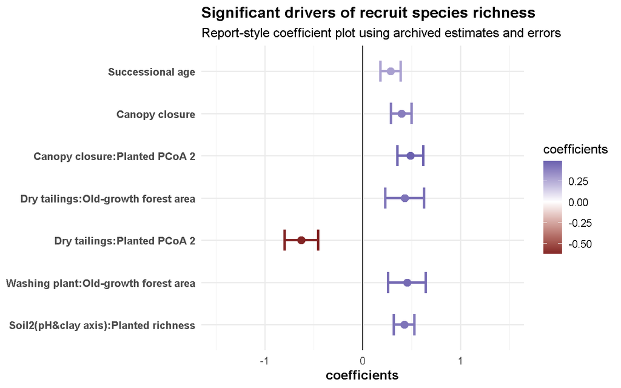

```r
plot_report_coefficients(
  sheet = "richness",
  title = "Significant drivers of recruit species richness",
  subtitle = "Report-style coefficient plot using archived estimates and errors",
  xlim = c(-1.5, 1.5)
)
```

#### Recruit species composition: PCoA axis 1

Positive coefficients indicate a shift toward *Psidium guianensis*-dominated recruit communities. Negative coefficients indicate a shift toward *Myrcia splendens*-dominated recruit communities.

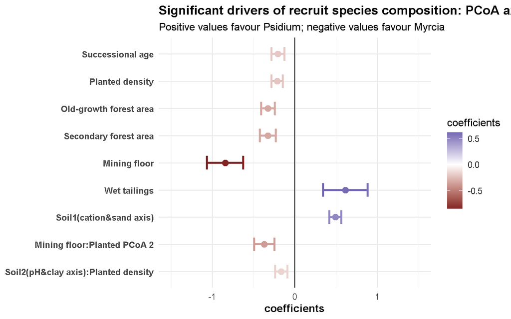

```r
plot_report_coefficients(
  sheet = "sc1",
  title = "Significant drivers of recruit species composition: PCoA axis 1",
  subtitle = "Positive values favour Psidium; negative values favour Myrcia",
  xlim = c(-1.5, 1.5)
)
```

#### Recruit species composition: PCoA axis 2

Positive coefficients indicate a shift toward *Siparuna guianensis* and *Vismia guianensis*-dominated recruit communities. Negative coefficients indicate a shift toward *Toulicia guianensis*-dominated communities.

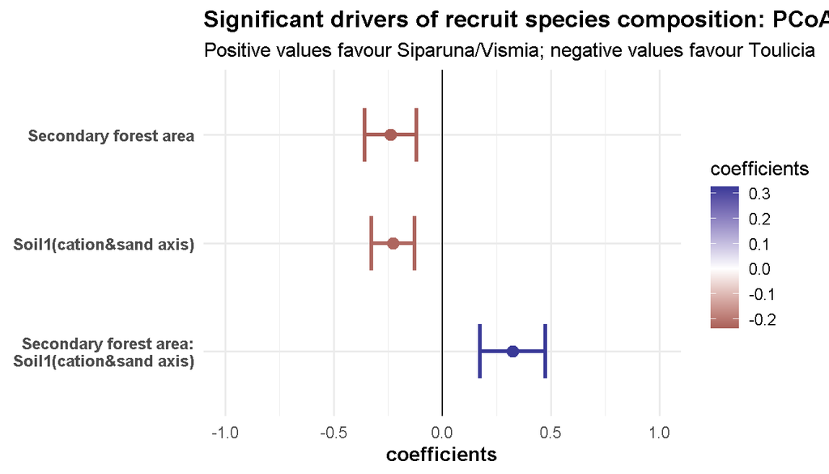

```r
plot_report_coefficients(
  sheet = "sc2",
  title = "Significant drivers of recruit species composition: PCoA axis 2",
  subtitle = "Positive values favour Siparuna/Vismia; negative values favour Toulicia",
  xlim = c(-1.0, 1.0)
)
```

#### Recruit density

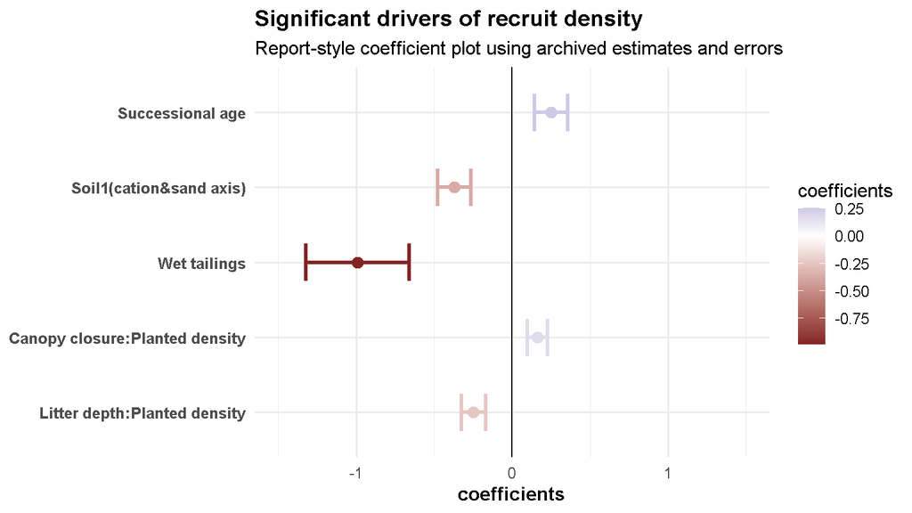

```r
plot_report_coefficients(
  sheet = "density",
  title = "Significant drivers of recruit density",
  subtitle = "Report-style coefficient plot using archived estimates and errors",
  xlim = c(-1.5, 1.5)
)
```

### 9.3 Model fit summary from archived thesis outputs

The archived `r2` sheet stores the marginal and conditional coefficients of explanation reported for each model.

```r
read_excel(estimates_file, sheet = "r2") %>%
  mutate(
    r2m = round(r2m, 3),
    r2c = round(r2c, 3),
    `mines effect` = round(`mines effect`, 3)
  ) %>%
  knitr::kable(
    caption = "Archived marginal and conditional R² values for the final thesis models."
  )
```

Archived marginal and conditional R² values for the final thesis models.

| model | r2m | r2c | mines effect |
| --- | --- | --- | --- |
| richness | 0.503 | 0.503 | 0.000 |
| sc1 | 0.756 | 0.776 | 0.019 |
| sc2 | 0.299 | 0.346 | 0.046 |
| density | 0.415 | 0.444 | 0.029 |

### 9.4 Live coefficient plots from the fitted model objects

The following plots are generated directly from the `lme` model objects fitted in this Rmd. They are useful for reproducibility checks, but they are not the primary report-style figures. Differences from the archived figures can arise from stepwise-selection details, factor-reference levels, coefficient naming, package versions, or manual rounding in the thesis figure-preparation file.

```r
extract_lme_coefficients <- function(model, drop_intercept = TRUE) {
  out <- as.data.frame(coef(summary(model))) %>%
    rownames_to_column("variables") %>%
    rename(
      estimate = Value,
      std_error = Std.Error,
      df = DF,
      t_value = `t-value`,
      p_value = `p-value`
    )

  if (drop_intercept) {
    out <- out %>% filter(variables != "(Intercept)")
  }

  out %>%
    mutate(
      variables = fct_inorder(variables),
      variables = fct_rev(variables)
    )
}

plot_live_coefficients <- function(model, title, subtitle = NULL, xlim = NULL) {
  coeff <- extract_lme_coefficients(model)

  p <- ggplot(
    coeff,
    aes(
      x = estimate,
      y = variables,
      xmin = estimate - std_error,
      xmax = estimate + std_error
    )
  ) +
    geom_vline(xintercept = 0, linewidth = 0.5) +
    geom_errorbarh(height = 0.4, aes(colour = estimate), linewidth = 1.1) +
    geom_point(aes(colour = estimate), size = 3) +
    scale_colour_gradient2() +
    labs(
      x = "Coefficient",
      y = NULL,
      colour = "Coefficient",
      title = title,
      subtitle = subtitle
    ) +
    theme_minimal(base_size = 12) +
    theme(axis.text.y = element_text(face = "bold"))

  if (!is.null(xlim)) {
    p <- p + coord_cartesian(xlim = xlim)
  }

  p
}
```

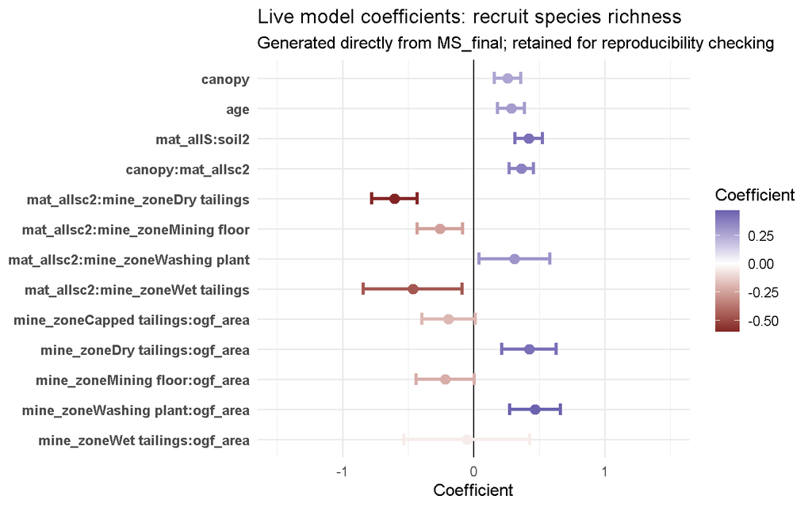

```r
plot_live_coefficients(
  MS_final,
  title = "Live model coefficients: recruit species richness",
  subtitle = "Generated directly from MS_final; retained for reproducibility checking",
  xlim = c(-1.5, 1.5)
)
```

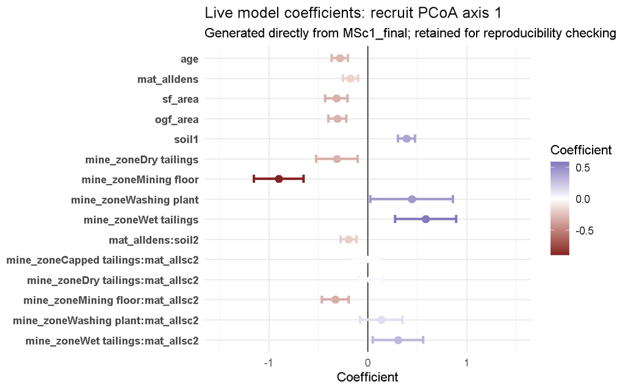

```r
plot_live_coefficients(
  MSc1_final,
  title = "Live model coefficients: recruit PCoA axis 1",
  subtitle = "Generated directly from MSc1_final; retained for reproducibility checking",
  xlim = c(-1.5, 1.5)
)
```

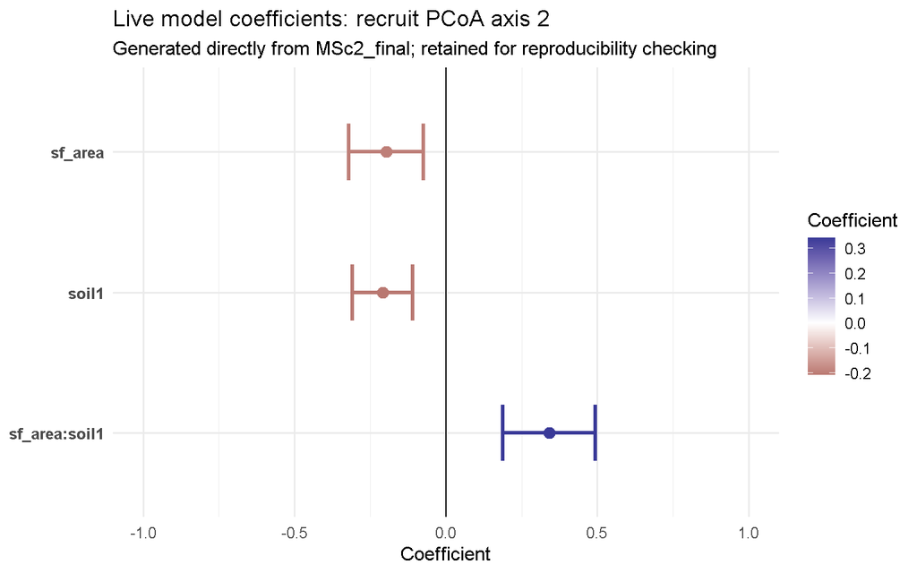

```r
plot_live_coefficients(
  MSc2_final,
  title = "Live model coefficients: recruit PCoA axis 2",
  subtitle = "Generated directly from MSc2_final; retained for reproducibility checking",
  xlim = c(-1.0, 1.0)
)
```

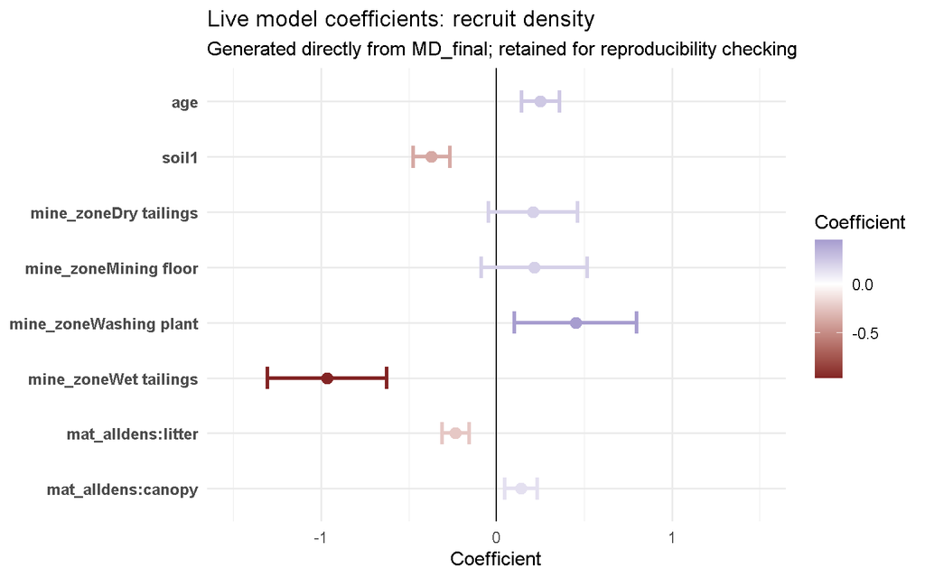

```r
plot_live_coefficients(
  MD_final,
  title = "Live model coefficients: recruit density",
  subtitle = "Generated directly from MD_final; retained for reproducibility checking",
  xlim = c(-1.5, 1.5)
)
```

## 10. Curated interaction plots

The original analysis included several interaction plots that were not all included in the main thesis report. Only the interactions retained in the final models are shown here. They help explain ecological mechanisms that are hard to interpret from coefficient plots alone.

These plots use the raw, interpretable variables on the axes where possible. They are therefore explanatory visualisations, not replacements for the final mixed-effects models.

```r
make_tertile <- function(x, labels = c("Low", "Medium", "High")) {
  x_num <- as_numeric_vector(x)
  out <- rep(NA_character_, length(x_num))
  ok <- is.finite(x_num)
  if (sum(ok) >= 3) {
    groups <- dplyr::ntile(x_num[ok], 3)
    out[ok] <- labels[groups]
  }
  factor(out, levels = labels)
}

# Colour palettes are kept explicit for the interaction plots because the
# original graphing script used visible group colours to distinguish fitted
# relationships. Confidence bands are shown with geom_smooth(se = TRUE).
interaction_palette_3 <- c("chartreuse", "chartreuse3", "darkgreen")

mine_zone_palette <- c(
  "Capped tailings" = "#1b9e77",
  "Dry tailings" = "#d95f02",
  "Mining floor" = "#7570b3",
  "Washing plant" = "#66a61e",
  "Wet tailings" = "#e7298a"
)

data <- data %>%
  mutate(
    planted_density_group = make_tertile(planted_density, c("Low planted density", "Medium planted density", "High planted density")),
    planted_pcoa2_group = make_tertile(mature_all_sc2, c("Low planted PCoA2", "Medium planted PCoA2", "High planted PCoA2")),
    planted_richness_group = make_tertile(mature_all_S, c("Low planted richness", "Medium planted richness", "High planted richness")),
    secondary_forest_group = make_tertile(area_sf, c("Low secondary forest", "Medium secondary forest", "High secondary forest"))
  )
```

### 10.1 Interactions retained in the recruit richness model

The richness model retained interactions between canopy closure and planted PCoA2, mine zone and old-growth forest area, and soil axis 2 and planted richness.

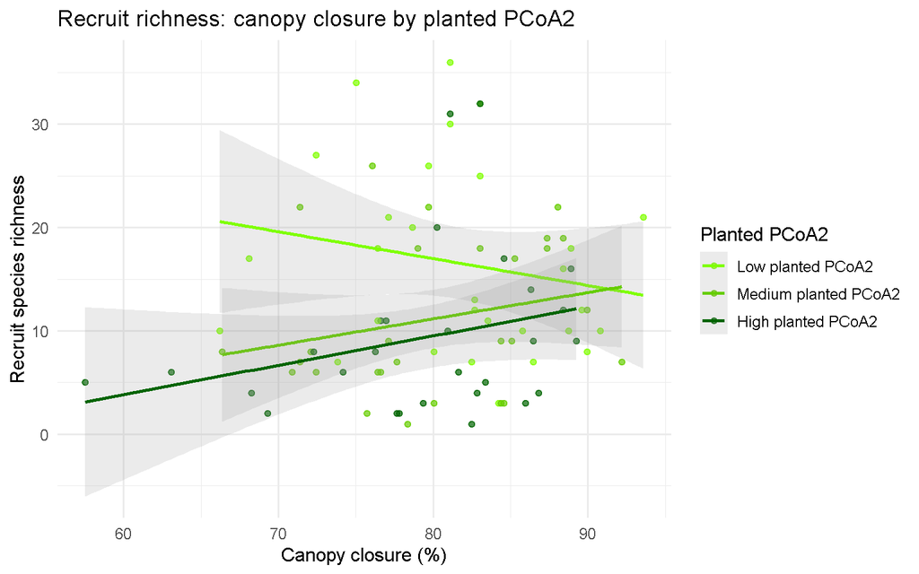

```r
ggplot(data, aes(x = canopy_closure, y = recruits12_S, colour = planted_pcoa2_group)) +
  geom_point(alpha = 0.7) +
  geom_smooth(method = "lm", se = TRUE, linewidth = 1, alpha = 0.20) +
  labs(
    title = "Recruit richness: canopy closure by planted PCoA2",
    x = "Canopy closure (%)",
    y = "Recruit species richness",
    colour = "Planted PCoA2"
  ) +
  scale_colour_manual(values = interaction_palette_3, drop = FALSE) +
  theme_minimal(base_size = 12)
```

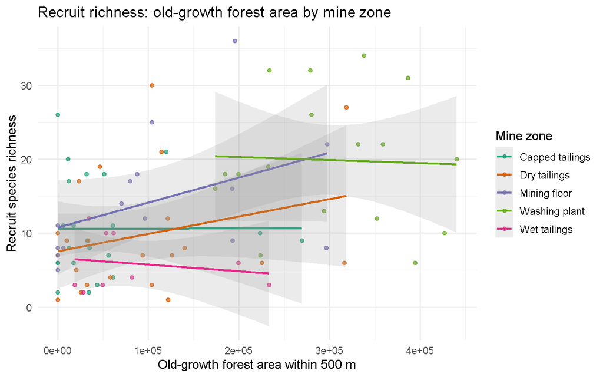

```r
ggplot(data, aes(x = area_ogf, y = recruits12_S, colour = mine_zone)) +
  geom_point(alpha = 0.7) +
  geom_smooth(method = "lm", se = TRUE, linewidth = 1, alpha = 0.20) +
  labs(
    title = "Recruit richness: old-growth forest area by mine zone",
    x = "Old-growth forest area within 500 m",
    y = "Recruit species richness",
    colour = "Mine zone"
  ) +
  scale_colour_manual(values = mine_zone_palette, drop = FALSE) +
  theme_minimal(base_size = 12)
```

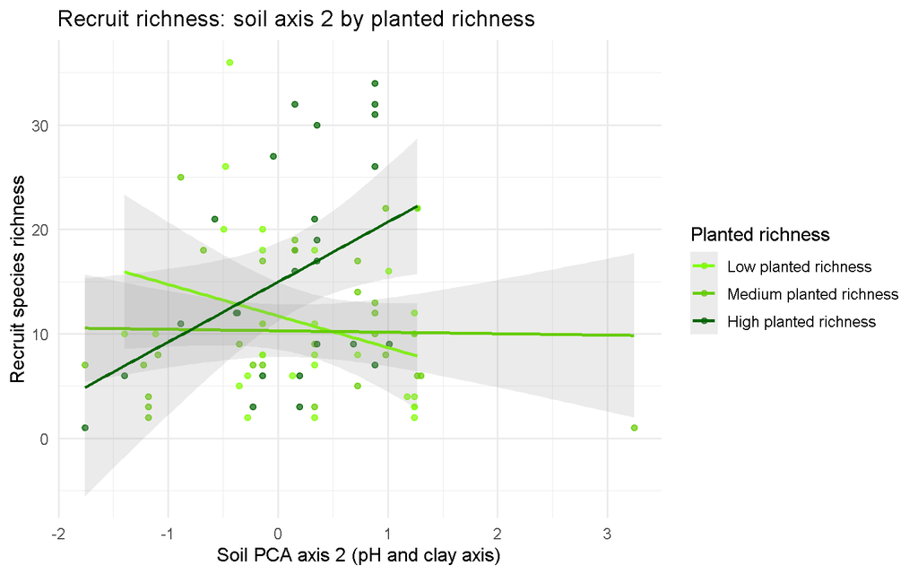

```r
ggplot(data, aes(x = soil_pca2, y = recruits12_S, colour = planted_richness_group)) +
  geom_point(alpha = 0.7) +
  geom_smooth(method = "lm", se = TRUE, linewidth = 1, alpha = 0.20) +
  labs(
    title = "Recruit richness: soil axis 2 by planted richness",
    x = "Soil PCA axis 2 (pH and clay axis)",
    y = "Recruit species richness",
    colour = "Planted richness"
  ) +
  scale_colour_manual(values = interaction_palette_3, drop = FALSE) +
  theme_minimal(base_size = 12)
```

### 10.2 Interactions retained in the recruit PCoA 1 model

The PCoA 1 model retained interactions between planted density and soil axis 2, and between mine zone and planted PCoA2.

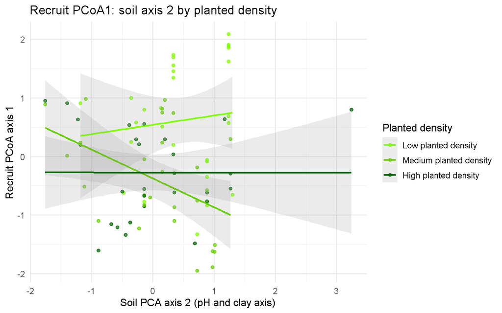

```r
ggplot(data, aes(x = soil_pca2, y = recruits12_sc1, colour = planted_density_group)) +
  geom_point(alpha = 0.7) +
  geom_smooth(method = "lm", se = TRUE, linewidth = 1, alpha = 0.20) +
  labs(
    title = "Recruit PCoA1: soil axis 2 by planted density",
    x = "Soil PCA axis 2 (pH and clay axis)",
    y = "Recruit PCoA axis 1",
    colour = "Planted density"
  ) +
  scale_colour_manual(values = interaction_palette_3, drop = FALSE) +
  theme_minimal(base_size = 12)
```

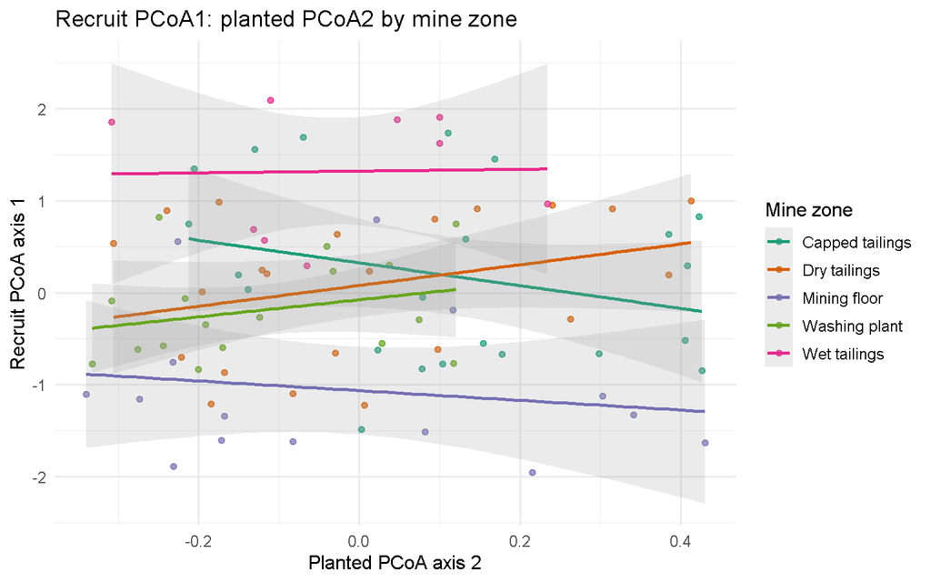

```r
ggplot(data, aes(x = mature_all_sc2, y = recruits12_sc1, colour = mine_zone)) +
  geom_point(alpha = 0.7) +
  geom_smooth(method = "lm", se = TRUE, linewidth = 1, alpha = 0.20) +
  labs(
    title = "Recruit PCoA1: planted PCoA2 by mine zone",
    x = "Planted PCoA axis 2",
    y = "Recruit PCoA axis 1",
    colour = "Mine zone"
  ) +
  scale_colour_manual(values = mine_zone_palette, drop = FALSE) +
  theme_minimal(base_size = 12)
```

### 10.3 Interaction retained in the recruit PCoA 2 model

The PCoA 2 model retained the interaction between secondary forest area and soil axis 1.

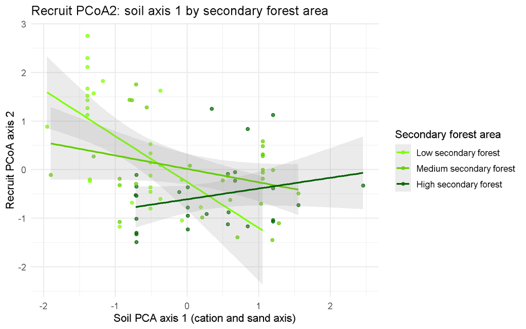

```r
ggplot(data, aes(x = soil_pca1, y = recruits12_sc2, colour = secondary_forest_group)) +
  geom_point(alpha = 0.7) +
  geom_smooth(method = "lm", se = TRUE, linewidth = 1, alpha = 0.20) +
  labs(
    title = "Recruit PCoA2: soil axis 1 by secondary forest area",
    x = "Soil PCA axis 1 (cation and sand axis)",
    y = "Recruit PCoA axis 2",
    colour = "Secondary forest area"
  ) +
  scale_colour_manual(values = interaction_palette_3, drop = FALSE) +
  theme_minimal(base_size = 12)
```

### 10.4 Interactions retained in the recruit density model

The density model retained two contrasting interactions: planted density with canopy closure, and planted density with litter depth.

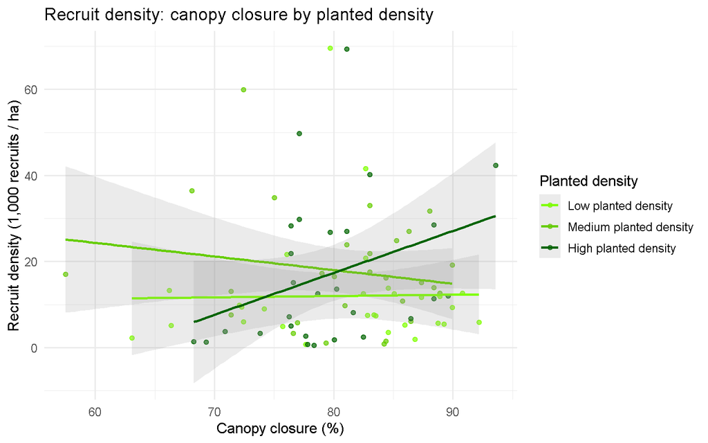

```r
ggplot(data, aes(x = canopy_closure, y = recruits12_density / 1000, colour = planted_density_group)) +
  geom_point(alpha = 0.7) +
  geom_smooth(method = "lm", se = TRUE, linewidth = 1, alpha = 0.20) +
  labs(
    title = "Recruit density: canopy closure by planted density",
    x = "Canopy closure (%)",
    y = "Recruit density (1,000 recruits / ha)",
    colour = "Planted density"
  ) +
  scale_colour_manual(values = interaction_palette_3, drop = FALSE) +
  theme_minimal(base_size = 12)
```

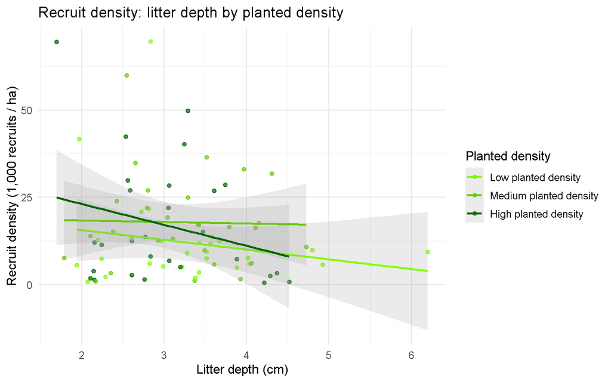

```r
ggplot(data, aes(x = litter_depth, y = recruits12_density / 1000, colour = planted_density_group)) +
  geom_point(alpha = 0.7) +
  geom_smooth(method = "lm", se = TRUE, linewidth = 1, alpha = 0.20) +
  labs(
    title = "Recruit density: litter depth by planted density",
    x = "Litter depth (cm)",
    y = "Recruit density (1,000 recruits / ha)",
    colour = "Planted density"
  ) +
  scale_colour_manual(values = interaction_palette_3, drop = FALSE) +
  theme_minimal(base_size = 12)
```

## 11. Additional exploratory plots

The plots below are useful as supporting diagnostics and ecological context. They should be treated as appendix material rather than core results.

### 11.1 Recruit density by mine zone

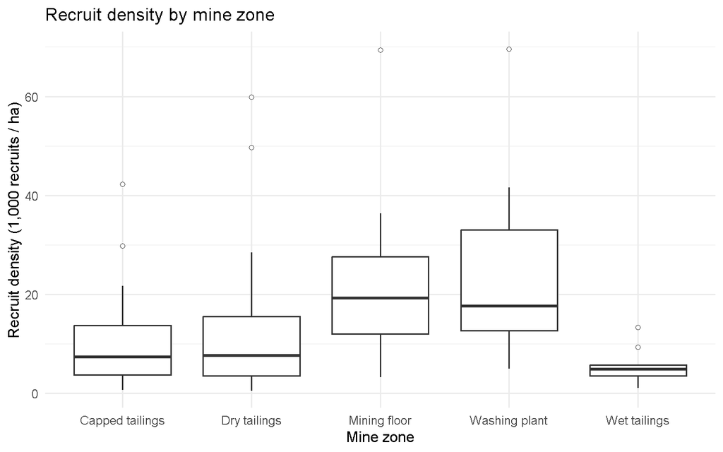

```r
ggplot(data, aes(x = mine_zone, y = recruits12_density / 1000)) +
  geom_boxplot(outlier.shape = 21) +
  labs(
    x = "Mine zone",
    y = "Recruit density (1,000 recruits / ha)",
    title = "Recruit density by mine zone"
  ) +
  theme_minimal(base_size = 12)
```

### 11.2 Raw litter-depth and canopy-closure relationships

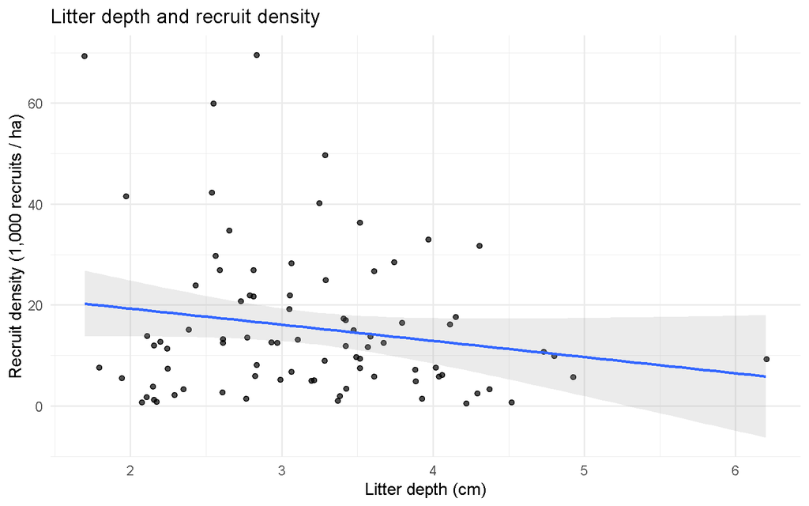

```r
ggplot(data, aes(x = litter_depth, y = recruits12_density / 1000)) +
  geom_point(size = 1.5, alpha = 0.7, position = "jitter") +
  geom_smooth(method = lm, se = TRUE, linewidth = 1, alpha = 0.2) +
  theme_minimal(base_size = 12) +
  labs(
    title = "Litter depth and recruit density",
    y = "Recruit density (1,000 recruits / ha)",
    x = "Litter depth (cm)"
  )
```

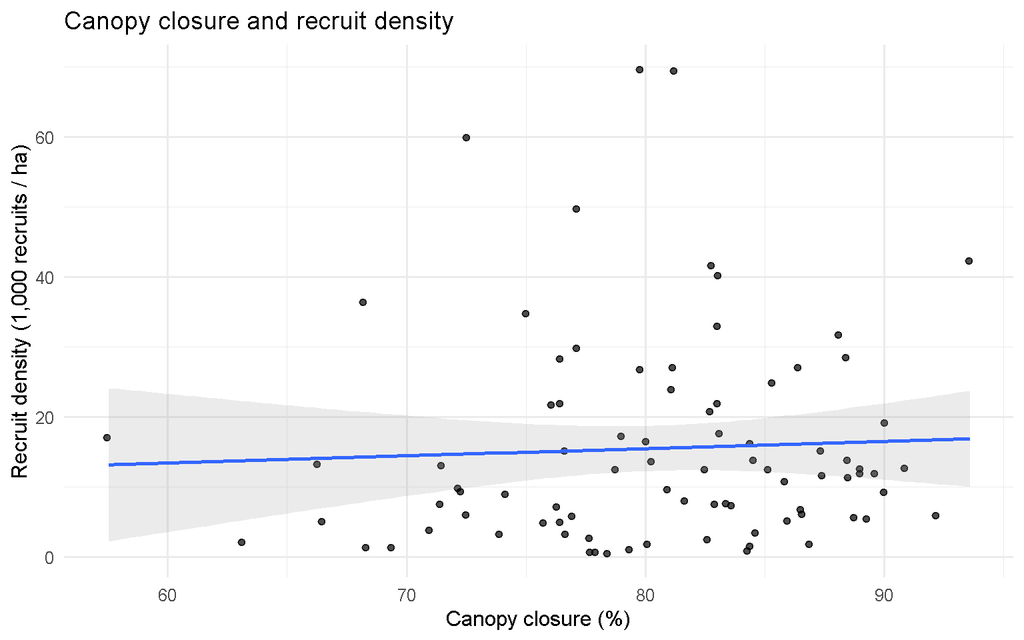

```r
ggplot(data, aes(x = canopy_closure, y = recruits12_density / 1000)) +
  geom_point(size = 1.5, alpha = 0.7, position = "jitter") +
  geom_smooth(method = lm, se = TRUE, linewidth = 1, alpha = 0.2) +
  theme_minimal(base_size = 12) +
  labs(
    title = "Canopy closure and recruit density",
    y = "Recruit density (1,000 recruits / ha)",
    x = "Canopy closure (%)"
  )
```

## 12. Interpretation of final results

### Recruit species richness

Recruit richness was positively associated with successional age and canopy closure. The final model also retained interactions between planted-tree community composition, canopy closure, soil axis 2, old-growth forest area and mine zone. Ecologically, this indicates that recruitment diversity was not driven by a single factor. It depended on a combination of time since restoration, light conditions, soil context, planted-tree community structure and surrounding forest availability.

### Recruit species composition

Recruit PCoA 1 was strongly associated with soil axis 1, mine zone, successional age, planted-tree density and surrounding forest area. In the thesis interpretation, positive PCoA 1 values reflected *Psidium guianensis*-dominated recruitment, while negative values reflected *Myrcia splendens*-dominated recruitment.

Recruit PCoA 2 was mainly explained by secondary forest area, soil axis 1 and their interaction. This supports the interpretation that surrounding secondary forests influenced recruit composition, especially where soil conditions created suitable establishment filters.

### Recruit density

Recruit density increased with successional age, declined along the cation-and-sand soil axis, and differed among mine zones. The two most management-relevant terms were the interactions between planted-tree density and the light-related variables. Planted-tree density interacted positively with canopy closure but negatively with litter depth, suggesting a trade-off in which planted-tree structure can facilitate recruitment under some canopy conditions but suppress recruitment where litter accumulation is high.

## 13. Methods summary

| Step | Implementation in the R workflow |
| --- | --- |
| Data import | `read_excel()` from the `canopy` sheet |
| Ordination inputs | Soil PCA and species PCoA axes imported as model variables |
| Distribution checks | `summary()`, `hist()`, `shapiro.test()` |
| Transformations | log, arcsine-square-root, square-root and fourth-root transformations |
| Standardisation | `scale()` applied to continuous variables |
| Collinearity | `vif.lme()` custom function from the original script |
| Random effects | GLS vs mine random intercept vs mine/area nested random intercept |
| Variable selection | backward stepwise selection with `lmerTest::step()` |
| Final estimation | `nlme::lme(..., method = "REML")` |
| Main graphs | report-style coefficient plots from `estimates_errors.xlsx` |
| Reproducibility graphs | live coefficient plots from fitted `lme` objects |
| Interaction plots | retained interactions from the final models |

## 14. Reference

Villamonte Cuneo, G. O. (2020). *Forest restoration of Amazonian mine lands: Identifying factors driving tree recruitment*. Wageningen University & Research, Forest Ecology and Forest Management Group.